# Technical Stack

## Author: Ram Saran Vuppuluri

### Introduction

Kaggle had initiated an industry-wide survey in 2017 that presents a truly comprehensive view of the state of data science and machine learning. In 2018, the study was live for a week in October and had collected responses from 23,859 individuals.

Data set used for the analysis is has 390+ columns. Not all columns are needed at any given point of the study. For this reason, the notebook is further divided into multiple subsections which will start with a business question, followed by data analysis. Only the columns that are related to the business question are extracted for analysis.

Furthermore, we are persisting extracted columns into separate csv files that are utilized for generating visualizations using Tableau for Medium blog post.

**One significant advantage with this approach is we are not ignoring the whole row if the respondent has not to answer specific questions. We are going to include all the answers (non-freeform) in the analysis.**

In this notebook, we will analyze the Technical Stack of the survey takers.

```python
import gc

import pandas as pd
import matplotlib.pyplot as plt
import seaborn as sns
%matplotlib inline

import warnings
warnings.filterwarnings('ignore')
```

```python
def generate_vertical_countplot(x, xlabel='', figName=None, figSize=(8, 6)):
    '''
    This method will generate vertical Seaborn countplot.

    :param x: x parameter

    :param xlabel: x axis label

    :param figName: file name by which it need to be stored.

    :param figSize: plot figure size.

    :return: None
    '''
    sns.set(rc={'figure.figsize': figSize})

    ax = sns.countplot(x=x)

    plt.xlabel(xlabel)
    if figName != None:
        ax.get_figure().savefig(figName)
    plt.show(ax);
```

```python
def generate_horizontal_countplot(y, ylabel='', figName=None, figSize=(12, 10)):
    '''
    This method will generate horizontal Seaborn countplot/

    :param y: y parameter

    :param ylabel: y axis label

    :param figName: file name by which it need to be stored

    :param figSize: plot figure size.

    :return: None
    '''
    sns.set(rc={'figure.figsize': figSize})

    ax = sns.countplot(y=y)

    plt.ylabel(ylabel)

    if figName != None:
        ax.get_figure().savefig(figName)
    plt.show(ax);
```

```python
def generate_bar_plot(data, x, y, xlabel='', ylabel='', figName=None, figSize=(12, 10)):
    '''
    This method will generate Seaborn Bar plot.

    :param data: Pandas Dataframe.

    :param x: x parameter

    :param y: y parameter

    :param xlabel: x axis label

    :param ylabel: y axis label

    :param figName: file name by which it need to be stored

    :param figSize: plot figure size.

    :return: None
    '''
    sns.set(rc={'figure.figsize': figSize})
    ax = sns.barplot(x=x, y=y, data=data)
    plt.xlabel(xlabel)
    plt.ylabel(ylabel)
    ax.get_figure().savefig(figName)
    plt.show(ax);
```

```python
multipleChoiceDF = pd.read_csv('../multipleChoiceResponses.csv',low_memory=False)
```

### Which of the following integrated development environments (IDE's) have you used at work or school in the last 5 years?

- **Jupyter/IPython**
- **RStudio**
- **PyCharm**
- **Visual Studio Code**
- **nteract**
- **Atom**
- **MATLAB**
- **Visual Studio**
- **Notepad++**
- **Sublime Text**
- **Vim**
- **IntelliJ**
- **Spyder**
- **None**
- **Other**

```python
ideDF = multipleChoiceDF[['Q13_Part_1', 'Q13_Part_2','Q13_Part_3', 'Q13_Part_4','Q13_Part_5', 'Q13_Part_6',
                          'Q13_Part_7','Q13_Part_8','Q13_Part_9','Q13_Part_10','Q13_Part_11','Q13_Part_12',
                          'Q13_Part_13','Q13_Part_14','Q13_Part_15']]
```

```python
ideDF.head()
```

|  | Q13_Part_1 | Q13_Part_2 | Q13_Part_3 | Q13_Part_4 | Q13_Part_5 | Q13_Part_6 | Q13_Part_7 | Q13_Part_8 | Q13_Part_9 | Q13_Part_10 | Q13_Part_11 | Q13_Part_12 | Q13_Part_13 | Q13_Part_14 | Q13_Part_15 |
| --- | --- | --- | --- | --- | --- | --- | --- | --- | --- | --- | --- | --- | --- | --- | --- |
| 0 | Which of the following integrated development ... | Which of the following integrated development ... | Which of the following integrated development ... | Which of the following integrated development ... | Which of the following integrated development ... | Which of the following integrated development ... | Which of the following integrated development ... | Which of the following integrated development ... | Which of the following integrated development ... | Which of the following integrated development ... | Which of the following integrated development ... | Which of the following integrated development ... | Which of the following integrated development ... | Which of the following integrated development ... | Which of the following integrated development ... |
| 1 | Jupyter/IPython | NaN | NaN | NaN | NaN | NaN | NaN | NaN | NaN | NaN | NaN | NaN | NaN | NaN | NaN |
| 2 | NaN | NaN | NaN | NaN | NaN | NaN | NaN | NaN | NaN | NaN | NaN | NaN | NaN | None | NaN |
| 3 | NaN | NaN | NaN | NaN | NaN | NaN | MATLAB | NaN | NaN | NaN | NaN | NaN | NaN | NaN | NaN |
| 4 | Jupyter/IPython | RStudio | PyCharm | NaN | NaN | NaN | NaN | Visual Studio | NaN | NaN | Vim | NaN | NaN | NaN | NaN |

```python
ideDF.info()
```

```
<class 'pandas.core.frame.DataFrame'>
RangeIndex: 23860 entries, 0 to 23859
Data columns (total 15 columns):
Q13_Part_1     14011 non-null object
Q13_Part_2     8504 non-null object
Q13_Part_3     7061 non-null object
Q13_Part_4     5083 non-null object
Q13_Part_5     128 non-null object
Q13_Part_6     3907 non-null object
Q13_Part_7     5672 non-null object
Q13_Part_8     5112 non-null object
Q13_Part_9     7832 non-null object
Q13_Part_10    5986 non-null object
Q13_Part_11    4241 non-null object
Q13_Part_12    3457 non-null object
Q13_Part_13    5340 non-null object
Q13_Part_14    475 non-null object
Q13_Part_15    1258 non-null object
dtypes: object(15)
memory usage: 2.7+ MB
```

From the visual and programmatic analysis:

- There are rows with missing data, but deviating from data we explored till now, missing information is expected per record as selections are optional. We will melt into one single column removing missing values, and use this column for analysis.
- All columns are loaded with the correct data type.
- Row with ID 0, is the same as the question. We will drop this row from the analysis as it does not have any empirical value.
- Column names are not informative, we will rename columns with more informative names.

```python
ideDF.drop([0],inplace=True)
ideDF.reset_index(drop=True,inplace=True)
```

```python
ideDF = pd.melt(ideDF)
```

```python
ideDF.head()
```

|  | variable | value |
| --- | --- | --- |
| 0 | Q13_Part_1 | Jupyter/IPython |
| 1 | Q13_Part_1 | NaN |
| 2 | Q13_Part_1 | NaN |
| 3 | Q13_Part_1 | Jupyter/IPython |
| 4 | Q13_Part_1 | NaN |

```python
ideDF.drop(columns=['variable'],inplace=True)
```

```python
ideDF.head()
```

|  | value |
| --- | --- |
| 0 | Jupyter/IPython |
| 1 | NaN |
| 2 | NaN |
| 3 | Jupyter/IPython |
| 4 | NaN |

```python
ideDF.dropna(inplace=True)
ideDF.reset_index(drop=True,inplace=True)
```

```python
ideDF.head()
```

|  | value |
| --- | --- |
| 0 | Jupyter/IPython |
| 1 | Jupyter/IPython |
| 2 | Jupyter/IPython |
| 3 | Jupyter/IPython |
| 4 | Jupyter/IPython |

**Every language has its syntax and semantics, and as humans, it’s not possible to memorize them. Integrated Development Environments (IDEs) are developed to avoid syntactical and semantical mistakes and increase productivity.**

**Most of the businesses use IDEs for development. IDEs help to increase the overall productivity of developers.**

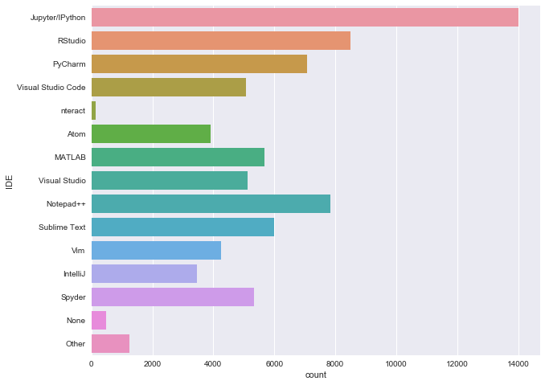

```python
generate_horizontal_countplot(y=ideDF.value,
                             figSize=(10,8),
                             ylabel = 'IDE',
                             figName = 'ide.jpeg')
```

We will persist the clean copy of the dataframe as a CSV file.

We no longer need "ideDF" in the analysis. We will clean up from memory.

```python
ideDF.to_csv('ide.csv',index=False)
```

```python
del ideDF
gc.collect()
```

```
3613
```

### Which of the following hosted notebooks have you used at work or school in the last 5 years?

- **Kaggle Kernels**
- **Google Colab**
- **Azure Notebook**
- **Domino Datalab**
- **Google Cloud Datalab**
- **Paperspace**
- **Floydhub**
- **Crestle**
- **JupyterHub/Binder**
- **None**
- **Other**

```python
notebookDF = multipleChoiceDF[['Q14_Part_1', 'Q14_Part_2','Q14_Part_3', 'Q14_Part_4','Q14_Part_5', 'Q14_Part_6',
                               'Q14_Part_7','Q14_Part_8','Q14_Part_9','Q14_Part_10','Q14_Part_11']]
```

```python
notebookDF.head()
```

|  | Q14_Part_1 | Q14_Part_2 | Q14_Part_3 | Q14_Part_4 | Q14_Part_5 | Q14_Part_6 | Q14_Part_7 | Q14_Part_8 | Q14_Part_9 | Q14_Part_10 | Q14_Part_11 |
| --- | --- | --- | --- | --- | --- | --- | --- | --- | --- | --- | --- |
| 0 | Which of the following hosted notebooks have y... | Which of the following hosted notebooks have y... | Which of the following hosted notebooks have y... | Which of the following hosted notebooks have y... | Which of the following hosted notebooks have y... | Which of the following hosted notebooks have y... | Which of the following hosted notebooks have y... | Which of the following hosted notebooks have y... | Which of the following hosted notebooks have y... | Which of the following hosted notebooks have y... | Which of the following hosted notebooks have y... |
| 1 | NaN | NaN | NaN | NaN | NaN | NaN | NaN | NaN | NaN | None | NaN |
| 2 | NaN | NaN | NaN | NaN | NaN | NaN | NaN | NaN | NaN | None | NaN |
| 3 | NaN | NaN | NaN | NaN | NaN | NaN | NaN | NaN | NaN | None | NaN |
| 4 | Kaggle Kernels | Google Colab | NaN | NaN | NaN | NaN | NaN | NaN | NaN | NaN | NaN |

```python
notebookDF.info()
```

```
<class 'pandas.core.frame.DataFrame'>
RangeIndex: 23860 entries, 0 to 23859
Data columns (total 11 columns):
Q14_Part_1     6043 non-null object
Q14_Part_2     3533 non-null object
Q14_Part_3     1305 non-null object
Q14_Part_4     120 non-null object
Q14_Part_5     1308 non-null object
Q14_Part_6     481 non-null object
Q14_Part_7     362 non-null object
Q14_Part_8     139 non-null object
Q14_Part_9     4917 non-null object
Q14_Part_10    7598 non-null object
Q14_Part_11    691 non-null object
dtypes: object(11)
memory usage: 2.0+ MB
```

From the visual and programmatic analysis:

- There are rows with missing data, but deviating from data we explored till now, missing information is expected per record as selections are optional. We will melt into one single column removing missing values, and use this column for analysis.
- All columns are loaded with the correct data type.
- Row with ID 0, is the same as the question. We will drop this row from the analysis as it does not have any empirical value.
- Column names are not informative, we will rename columns with more informative names.

```python
notebookDF.drop([0],inplace=True)
notebookDF.reset_index(drop=True,inplace=True)
```

```python
notebookDF.head()
```

|  | Q14_Part_1 | Q14_Part_2 | Q14_Part_3 | Q14_Part_4 | Q14_Part_5 | Q14_Part_6 | Q14_Part_7 | Q14_Part_8 | Q14_Part_9 | Q14_Part_10 | Q14_Part_11 |
| --- | --- | --- | --- | --- | --- | --- | --- | --- | --- | --- | --- |
| 0 | NaN | NaN | NaN | NaN | NaN | NaN | NaN | NaN | NaN | None | NaN |
| 1 | NaN | NaN | NaN | NaN | NaN | NaN | NaN | NaN | NaN | None | NaN |
| 2 | NaN | NaN | NaN | NaN | NaN | NaN | NaN | NaN | NaN | None | NaN |
| 3 | Kaggle Kernels | Google Colab | NaN | NaN | NaN | NaN | NaN | NaN | NaN | NaN | NaN |
| 4 | NaN | NaN | Azure Notebook | NaN | NaN | NaN | NaN | NaN | NaN | NaN | NaN |

```python
notebookDF = pd.melt(notebookDF)
```

```python
notebookDF.head()
```

|  | variable | value |
| --- | --- | --- |
| 0 | Q14_Part_1 | NaN |
| 1 | Q14_Part_1 | NaN |
| 2 | Q14_Part_1 | NaN |
| 3 | Q14_Part_1 | Kaggle Kernels |
| 4 | Q14_Part_1 | NaN |

```python
notebookDF.drop(columns=['variable'],inplace=True)
```

```python
notebookDF.head()
```

|  | value |
| --- | --- |
| 0 | NaN |
| 1 | NaN |
| 2 | NaN |
| 3 | Kaggle Kernels |
| 4 | NaN |

```python
notebookDF.dropna(inplace=True)
notebookDF.reset_index(drop=True,inplace=True)
```

```python
notebookDF.rename(columns={"value":"Notebook_kernel"},inplace=True)
```

**In the initial experimental phase of Data Science projects, Notebook Kernels provide an interactive environment for exploring, analyzing and conceptualizing data. Notebooks also provide an easy way to document and share findings in more than one format.**

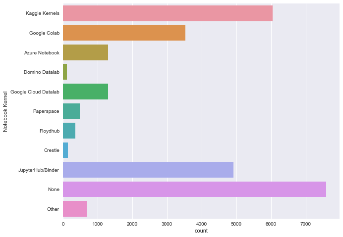

```python
generate_horizontal_countplot(y=notebookDF.Notebook_kernel,
                             figSize=(10,8),
                             ylabel = 'Notebook Kernel',
                             figName = 'notebook.jpeg')
```

We will persist the clean copy of the dataframe as a CSV file.

We no longer need "notebookDF" in the analysis. We will clean up from memory.

```python
notebookDF.to_csv('notebookDF.csv',index=False)
```

```python
del notebookDF
gc.collect()
```

```
3182
```

### Which of the following cloud computing services have you used at work or school in the last 5 years?

- **Google Cloud Platform (GCP)**
- **Amazon Web Services (AWS)**
- **Microsoft Azure**
- **IBM Cloud**
- **Alibaba Cloud**
- **I have not used any cloud providers**
- **Other**

```python
cloudDF = multipleChoiceDF[['Q15_Part_1', 'Q15_Part_2','Q15_Part_3', 'Q15_Part_4','Q15_Part_5', 'Q15_Part_6',
                            'Q15_Part_7']]
```

```python
cloudDF.head()
```

|  | Q15_Part_1 | Q15_Part_2 | Q15_Part_3 | Q15_Part_4 | Q15_Part_5 | Q15_Part_6 | Q15_Part_7 |
| --- | --- | --- | --- | --- | --- | --- | --- |
| 0 | Which of the following cloud computing service... | Which of the following cloud computing service... | Which of the following cloud computing service... | Which of the following cloud computing service... | Which of the following cloud computing service... | Which of the following cloud computing service... | Which of the following cloud computing service... |
| 1 | NaN | NaN | Microsoft Azure | NaN | NaN | NaN | NaN |
| 2 | NaN | NaN | NaN | NaN | NaN | I have not used any cloud providers | NaN |
| 3 | NaN | NaN | NaN | NaN | NaN | I have not used any cloud providers | NaN |
| 4 | Google Cloud Platform (GCP) | Amazon Web Services (AWS) | NaN | NaN | NaN | NaN | NaN |

```python
cloudDF.info()
```

```
<class 'pandas.core.frame.DataFrame'>
RangeIndex: 23860 entries, 0 to 23859
Data columns (total 7 columns):
Q15_Part_1    4784 non-null object
Q15_Part_2    7461 non-null object
Q15_Part_3    3806 non-null object
Q15_Part_4    1205 non-null object
Q15_Part_5    550 non-null object
Q15_Part_6    7104 non-null object
Q15_Part_7    777 non-null object
dtypes: object(7)
memory usage: 1.3+ MB
```

From the visual and programmatic analysis:

- There are rows with missing data, but deviating from data we explored till now, missing information is expected per record as selections are optional. We will melt into one single column removing missing values, and use this column for analysis.
- All columns are loaded with the correct data type.
- Row with ID 0, is the same as the question. We will drop this row from the analysis as it does not have any empirical value.
- Column names are not informative, we will rename columns with more informative names.

```python
cloudDF.drop([0],inplace=True)
```

```python
cloudDF.reset_index(drop=True,inplace=True)
```

```python
cloudDF = pd.melt(cloudDF)
```

```python
cloudDF.head()
```

|  | variable | value |
| --- | --- | --- |
| 0 | Q15_Part_1 | NaN |
| 1 | Q15_Part_1 | NaN |
| 2 | Q15_Part_1 | NaN |
| 3 | Q15_Part_1 | Google Cloud Platform (GCP) |
| 4 | Q15_Part_1 | NaN |

```python
cloudDF.drop(columns=['variable'],inplace=True)
```

```python
cloudDF.rename(columns={"value":"Cloud_Platform"},inplace=True)
cloudDF.dropna(inplace=True)
cloudDF.reset_index(drop=True,inplace=True)
```

```python
cloudDF.head()
```

|  | Cloud_Platform |
| --- | --- |
| 0 | Google Cloud Platform (GCP) |
| 1 | Google Cloud Platform (GCP) |
| 2 | Google Cloud Platform (GCP) |
| 3 | Google Cloud Platform (GCP) |
| 4 | Google Cloud Platform (GCP) |

**Cloud platform provides storage and computing power on a shared network of servers. In theory, there should be no shortage of storage space & computational power.**

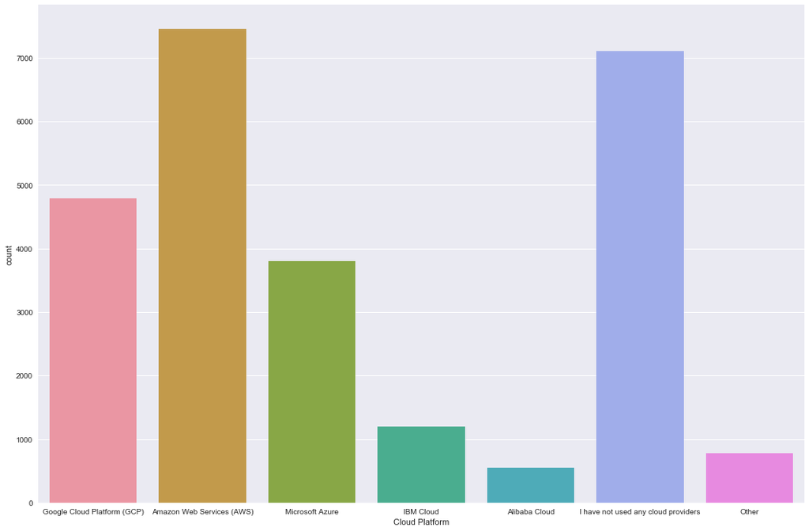

```python
generate_vertical_countplot(x=cloudDF.Cloud_Platform,
                            xlabel="Cloud Platform",
                            figName='Cloud_Platform.jpeg',
                            figSize=(18,12))
```

We will persist the clean copy of the dataframe as a CSV file.

We no longer need "cloudDF" in the analysis. We will clean up from memory.

```python
cloudDF.to_csv('cloud.csv',index=False)
```

```python
del cloudDF
gc.collect()
```

```
2730
```

### What programming languages do you use on a regular basis?

- **Python**
- **R**
- **SQL**
- **Bash**
- **Java**
- **Javascript/Typescript**
- **Visual Basic/VBA**
- **C/C++**
- **MATLAB**
- **Scala**
- **Julia**
- **Go**
- **C#/.NET**
- **PHP**
- **Ruby**
- **SAS/STATA**
- **None**
- **Other**

```python
languageDF = multipleChoiceDF[['Q16_Part_1', 'Q16_Part_2','Q16_Part_3', 'Q16_Part_4','Q16_Part_5', 'Q16_Part_6',
                               'Q16_Part_7','Q16_Part_8','Q16_Part_9','Q16_Part_10','Q16_Part_11','Q16_Part_12',
                               'Q16_Part_13','Q16_Part_14','Q16_Part_15','Q16_Part_16','Q16_Part_17','Q16_Part_18']]
```

```python
languageDF.head()
```

|  | Q16_Part_1 | Q16_Part_2 | Q16_Part_3 | Q16_Part_4 | Q16_Part_5 | Q16_Part_6 | Q16_Part_7 | Q16_Part_8 | Q16_Part_9 | Q16_Part_10 | Q16_Part_11 | Q16_Part_12 | Q16_Part_13 | Q16_Part_14 | Q16_Part_15 | Q16_Part_16 | Q16_Part_17 | Q16_Part_18 |
| --- | --- | --- | --- | --- | --- | --- | --- | --- | --- | --- | --- | --- | --- | --- | --- | --- | --- | --- |
| 0 | What programming languages do you use on a reg... | What programming languages do you use on a reg... | What programming languages do you use on a reg... | What programming languages do you use on a reg... | What programming languages do you use on a reg... | What programming languages do you use on a reg... | What programming languages do you use on a reg... | What programming languages do you use on a reg... | What programming languages do you use on a reg... | What programming languages do you use on a reg... | What programming languages do you use on a reg... | What programming languages do you use on a reg... | What programming languages do you use on a reg... | What programming languages do you use on a reg... | What programming languages do you use on a reg... | What programming languages do you use on a reg... | What programming languages do you use on a reg... | What programming languages do you use on a reg... |
| 1 | NaN | NaN | NaN | NaN | NaN | NaN | NaN | NaN | NaN | NaN | NaN | NaN | NaN | NaN | NaN | NaN | None | NaN |
| 2 | NaN | NaN | SQL | NaN | NaN | NaN | NaN | NaN | NaN | NaN | NaN | NaN | NaN | NaN | NaN | NaN | NaN | NaN |
| 3 | NaN | R | NaN | NaN | Java | NaN | NaN | NaN | MATLAB | NaN | NaN | NaN | NaN | NaN | NaN | NaN | NaN | NaN |
| 4 | Python | R | SQL | Bash | NaN | Javascript/Typescript | NaN | NaN | NaN | NaN | NaN | NaN | NaN | NaN | NaN | NaN | NaN | NaN |

```python
languageDF.info()
```

```
<class 'pandas.core.frame.DataFrame'>
RangeIndex: 23860 entries, 0 to 23859
Data columns (total 18 columns):
Q16_Part_1     15712 non-null object
Q16_Part_2     6686 non-null object
Q16_Part_3     8268 non-null object
Q16_Part_4     2709 non-null object
Q16_Part_5     4000 non-null object
Q16_Part_6     3250 non-null object
Q16_Part_7     1275 non-null object
Q16_Part_8     4384 non-null object
Q16_Part_9     2653 non-null object
Q16_Part_10    789 non-null object
Q16_Part_11    231 non-null object
Q16_Part_12    395 non-null object
Q16_Part_13    1671 non-null object
Q16_Part_14    1209 non-null object
Q16_Part_15    343 non-null object
Q16_Part_16    1053 non-null object
Q16_Part_17    333 non-null object
Q16_Part_18    625 non-null object
dtypes: object(18)
memory usage: 3.3+ MB
```

From the visual and programmatic analysis:

- There are rows with missing data, but deviating from data we explored till now, missing information is expected per record as selections are optional. We will melt into one single column removing missing values, and use this column for analysis.
- All columns are loaded with the correct data type.
- Row with ID 0, is the same as the question. We will drop this row from the analysis as it does not have any empirical value.
- Column names are not informative, we will rename columns with more informative names.

```python
languageDF.drop([0],inplace=True)
```

```python
languageDF.head()
```

|  | Q16_Part_1 | Q16_Part_2 | Q16_Part_3 | Q16_Part_4 | Q16_Part_5 | Q16_Part_6 | Q16_Part_7 | Q16_Part_8 | Q16_Part_9 | Q16_Part_10 | Q16_Part_11 | Q16_Part_12 | Q16_Part_13 | Q16_Part_14 | Q16_Part_15 | Q16_Part_16 | Q16_Part_17 | Q16_Part_18 |
| --- | --- | --- | --- | --- | --- | --- | --- | --- | --- | --- | --- | --- | --- | --- | --- | --- | --- | --- |
| 1 | NaN | NaN | NaN | NaN | NaN | NaN | NaN | NaN | NaN | NaN | NaN | NaN | NaN | NaN | NaN | NaN | None | NaN |
| 2 | NaN | NaN | SQL | NaN | NaN | NaN | NaN | NaN | NaN | NaN | NaN | NaN | NaN | NaN | NaN | NaN | NaN | NaN |
| 3 | NaN | R | NaN | NaN | Java | NaN | NaN | NaN | MATLAB | NaN | NaN | NaN | NaN | NaN | NaN | NaN | NaN | NaN |
| 4 | Python | R | SQL | Bash | NaN | Javascript/Typescript | NaN | NaN | NaN | NaN | NaN | NaN | NaN | NaN | NaN | NaN | NaN | NaN |
| 5 | NaN | NaN | SQL | NaN | Java | NaN | NaN | NaN | NaN | NaN | NaN | NaN | NaN | NaN | NaN | NaN | NaN | NaN |

```python
languageDF.reset_index(drop=True,inplace=True)
```

```python
languageDF = pd.melt(languageDF)
```

```python
languageDF.head()
```

|  | variable | value |
| --- | --- | --- |
| 0 | Q16_Part_1 | NaN |
| 1 | Q16_Part_1 | NaN |
| 2 | Q16_Part_1 | NaN |
| 3 | Q16_Part_1 | Python |
| 4 | Q16_Part_1 | NaN |

```python
languageDF.drop(columns=['variable'],inplace=True)
languageDF.rename(columns={"value":"language"},inplace=True)
languageDF.dropna(inplace=True)
languageDF.reset_index(drop=True,inplace=True)
```

```python
languageDF.head()
```

|  | language |
| --- | --- |
| 0 | Python |
| 1 | Python |
| 2 | Python |
| 3 | Python |
| 4 | Python |

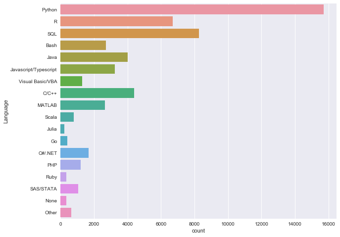

```python
generate_horizontal_countplot(y=languageDF.language,
                             figSize=(10,8),
                             ylabel = 'Language',
                             figName = 'language.jpeg')
```

We will persist the clean copy of the dataframe as a CSV file.

We no longer need "languageDF" in the analysis. We will clean up from memory.

```python
languageDF.to_csv('language.csv',index=False)
```

```python
del languageDF
gc.collect()
```

```
4023
```

### What specific programming language do you use most often?

```python
frequentLanguageDF = pd.DataFrame(multipleChoiceDF.Q17)
```

```python
frequentLanguageDF.head()
```

|  | Q17 |
| --- | --- |
| 0 | What specific programming language do you use ... |
| 1 | NaN |
| 2 | NaN |
| 3 | Java |
| 4 | Python |

```python
frequentLanguageDF.info()
```

```
<class 'pandas.core.frame.DataFrame'>
RangeIndex: 23860 entries, 0 to 23859
Data columns (total 1 columns):
Q17    15223 non-null object
dtypes: object(1)
memory usage: 186.5+ KB
```

From the visual and programmatic analysis:

- There are rows with missing data, we will not include these records in our report.
- All columns are loaded with the correct data type.
- Row with ID 0, is the same as the question. We will drop this row from the analysis as it does not have any empirical value.
- Column names are not informative, we will rename columns with more informative names.

```python
frequentLanguageDF.drop([0],inplace=True)
frequentLanguageDF.dropna(inplace=True)
frequentLanguageDF.reset_index(drop=True,inplace=True)
```

```python
frequentLanguageDF.rename(columns={"Q17":"Frequent_Language"},inplace=True)
```

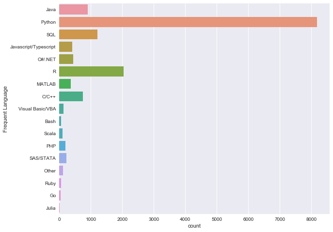

```python
generate_horizontal_countplot(y=frequentLanguageDF.Frequent_Language,
                             figSize=(10,8),
                             ylabel = 'Frequent Language',
                             figName = 'Frequent Language.jpeg')
```

We will persist the clean copy of the dataframe as a CSV file.

We no longer need "frequentLanguageDF" in the analysis. We will clean up from memory.

```python
frequentLanguageDF.to_csv('frequentLanguage.csv',index=False)
```

```python
del frequentLanguageDF
gc.collect()
```

```
3908
```

### What programming language would you recommend an aspiring data scientist to learn first?

```python
firstLanguageDF = pd.DataFrame(multipleChoiceDF.Q18)
```

```python
firstLanguageDF.head()
```

|  | Q18 |
| --- | --- |
| 0 | What programming language would you recommend ... |
| 1 | Python |
| 2 | Python |
| 3 | Python |
| 4 | SQL |

```python
firstLanguageDF.info()
```

```
<class 'pandas.core.frame.DataFrame'>
RangeIndex: 23860 entries, 0 to 23859
Data columns (total 1 columns):
Q18    18789 non-null object
dtypes: object(1)
memory usage: 186.5+ KB
```

From the visual and programmatic analysis:

- There are rows with missing data, we will not include these records in our report.
- All columns are loaded with the correct data type.
- Row with ID 0, is the same as the question. We will drop this row from the analysis as it does not have any empirical value.
- Column names are not informative, we will rename columns with more informative names.

```python
firstLanguageDF.drop([0],inplace=True)
firstLanguageDF.dropna(inplace=True)
firstLanguageDF.reset_index(drop=True,inplace=True)
```

```python
firstLanguageDF.rename(columns={"Q18":"first_language"},inplace=True)
```

```python
firstLanguageDF.head()
```

|  | first_language |
| --- | --- |
| 0 | Python |
| 1 | Python |
| 2 | Python |
| 3 | SQL |
| 4 | R |

**An overwhelming number of respondents have suggested Python as the first programming language to learn.**

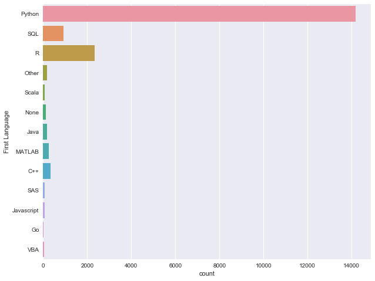

```python
generate_horizontal_countplot(y=firstLanguageDF.first_language,
                             figSize=(10,8),
                             ylabel = 'First Language',
                             figName = 'First_language.jpeg')
```

```python
firstLanguageDF.to_csv('firstLanguage.csv',index=False)
```

```python
del firstLanguageDF
gc.collect()
```

```
3386
```

### What machine learning frameworks have you used in the past 5 years?

- **Scikit-Learn**
- **TensorFlow**
- **Keras**
- **PyTorch**
- **Spark MLlib**
- **H20**
- **Fastai**
- **Mxnet**
- **Caret**
- **Xgboost**
- **mlr**
- **Prophet**
- **randomForest**
- **lightgbm**
- **catboost**
- **CNTK**
- **Caffe**
- **None**
- **Other**

```python
mlDF = multipleChoiceDF[['Q19_Part_1', 'Q19_Part_2','Q19_Part_3', 'Q19_Part_4','Q19_Part_5', 'Q19_Part_6',
                         'Q19_Part_7','Q19_Part_8','Q19_Part_9','Q19_Part_10','Q19_Part_11','Q19_Part_12',
                         'Q19_Part_13','Q19_Part_14','Q19_Part_15','Q19_Part_16','Q19_Part_17','Q19_Part_18',
                         'Q19_Part_19']]
```

```python
mlDF.head()
```

|  | Q19_Part_1 | Q19_Part_2 | Q19_Part_3 | Q19_Part_4 | Q19_Part_5 | Q19_Part_6 | Q19_Part_7 | Q19_Part_8 | Q19_Part_9 | Q19_Part_10 | Q19_Part_11 | Q19_Part_12 | Q19_Part_13 | Q19_Part_14 | Q19_Part_15 | Q19_Part_16 | Q19_Part_17 | Q19_Part_18 | Q19_Part_19 |
| --- | --- | --- | --- | --- | --- | --- | --- | --- | --- | --- | --- | --- | --- | --- | --- | --- | --- | --- | --- |
| 0 | What machine learning frameworks have you used... | What machine learning frameworks have you used... | What machine learning frameworks have you used... | What machine learning frameworks have you used... | What machine learning frameworks have you used... | What machine learning frameworks have you used... | What machine learning frameworks have you used... | What machine learning frameworks have you used... | What machine learning frameworks have you used... | What machine learning frameworks have you used... | What machine learning frameworks have you used... | What machine learning frameworks have you used... | What machine learning frameworks have you used... | What machine learning frameworks have you used... | What machine learning frameworks have you used... | What machine learning frameworks have you used... | What machine learning frameworks have you used... | What machine learning frameworks have you used... | What machine learning frameworks have you used... |
| 1 | NaN | NaN | NaN | NaN | NaN | NaN | NaN | NaN | NaN | NaN | NaN | NaN | NaN | NaN | NaN | NaN | NaN | None | NaN |
| 2 | NaN | NaN | NaN | NaN | NaN | NaN | NaN | NaN | NaN | NaN | NaN | NaN | NaN | NaN | NaN | NaN | NaN | None | NaN |
| 3 | NaN | NaN | NaN | NaN | NaN | NaN | NaN | NaN | NaN | NaN | NaN | NaN | NaN | NaN | NaN | NaN | NaN | None | NaN |
| 4 | Scikit-Learn | TensorFlow | Keras | NaN | Spark MLlib | NaN | NaN | NaN | NaN | Xgboost | NaN | NaN | NaN | NaN | NaN | NaN | NaN | NaN | NaN |

```python
mlDF.info()
```

```
<class 'pandas.core.frame.DataFrame'>
RangeIndex: 23860 entries, 0 to 23859
Data columns (total 19 columns):
Q19_Part_1     12250 non-null object
Q19_Part_2     9982 non-null object
Q19_Part_3     8137 non-null object
Q19_Part_4     3827 non-null object
Q19_Part_5     2056 non-null object
Q19_Part_6     1308 non-null object
Q19_Part_7     1100 non-null object
Q19_Part_8     595 non-null object
Q19_Part_9     2221 non-null object
Q19_Part_10    5572 non-null object
Q19_Part_11    529 non-null object
Q19_Part_12    733 non-null object
Q19_Part_13    5968 non-null object
Q19_Part_14    2100 non-null object
Q19_Part_15    1038 non-null object
Q19_Part_16    745 non-null object
Q19_Part_17    1102 non-null object
Q19_Part_18    2919 non-null object
Q19_Part_19    537 non-null object
dtypes: object(19)
memory usage: 3.5+ MB
```

From the visual and programmatic analysis:

- There are rows with missing data, but deviating from data we explored till now, missing information is expected per record as selections are optional. We will melt into one single column removing missing values, and use this column for analysis.
- All columns are loaded with the correct data type.
- Row with ID 0, is the same as the question. We will drop this row from the analysis as it does not have any empirical value.
- Column names are not informative, we will rename columns with more informative names.

```python
mlDF.drop([0],inplace=True)
mlDF.reset_index(drop=True,inplace=True)
```

```python
mlDF = pd.melt(mlDF)
```

```python
mlDF.head()
```

|  | variable | value |
| --- | --- | --- |
| 0 | Q19_Part_1 | NaN |
| 1 | Q19_Part_1 | NaN |
| 2 | Q19_Part_1 | NaN |
| 3 | Q19_Part_1 | Scikit-Learn |
| 4 | Q19_Part_1 | NaN |

```python
mlDF.drop(columns=['variable'],inplace=True)
```

```python
mlDF.rename(columns={'value':'ML_Framework'},inplace=True)
mlDF.dropna(inplace=True)
mlDF.reset_index(drop=True,inplace=True)
```

```python
mlDF.head()
```

|  | ML_Framework |
| --- | --- |
| 0 | Scikit-Learn |
| 1 | Scikit-Learn |
| 2 | Scikit-Learn |
| 3 | Scikit-Learn |
| 4 | Scikit-Learn |

**Machine Learning frameworks provide an abstract implementation of Supervised, Unsupervised and Deep Learning algorithms. Not every framework provides all the algorithms.**

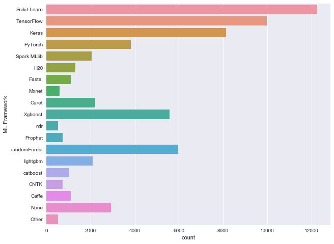

```python
generate_horizontal_countplot(y=mlDF.ML_Framework,
                             figSize=(10,8),
                             ylabel = 'ML Framework',
                             figName = 'ML_Framework.jpeg')
```

We will persist the clean copy of the dataframe as a CSV file.

We no longer need "mlDF" in the analysis. We will clean up from memory.

```python
mlDF.to_csv('ML_Framework.csv',index=False)
```

```python
del mlDF
gc.collect()
```

```
4000
```

### Of the choices that you selected in the previous question, which ML library have you used the most?

```python
frequentMLDF = pd.DataFrame(multipleChoiceDF.Q20)
```

```python
frequentMLDF.head()
```

|  | Q20 |
| --- | --- |
| 0 | Of the choices that you selected in the previo... |
| 1 | NaN |
| 2 | NaN |
| 3 | NaN |
| 4 | Scikit-Learn |

```python
frequentMLDF.info()
```

```
<class 'pandas.core.frame.DataFrame'>
RangeIndex: 23860 entries, 0 to 23859
Data columns (total 1 columns):
Q20    12990 non-null object
dtypes: object(1)
memory usage: 186.5+ KB
```

From the visual and programmatic analysis:

- There are rows with missing data, we will not include these records in our report.
- All columns are loaded with the correct data type.
- Row with ID 0, is the same as the question. We will drop this row from the analysis as it does not have any empirical value.
- Column names are not informative, we will rename columns with more informative names.

```python
frequentMLDF.drop([0],inplace=True)
frequentMLDF.dropna(inplace=True)
frequentMLDF.reset_index(inplace=True)
```

```python
frequentMLDF.rename(columns={"Q20":"frequent_ml"},inplace=True)
```

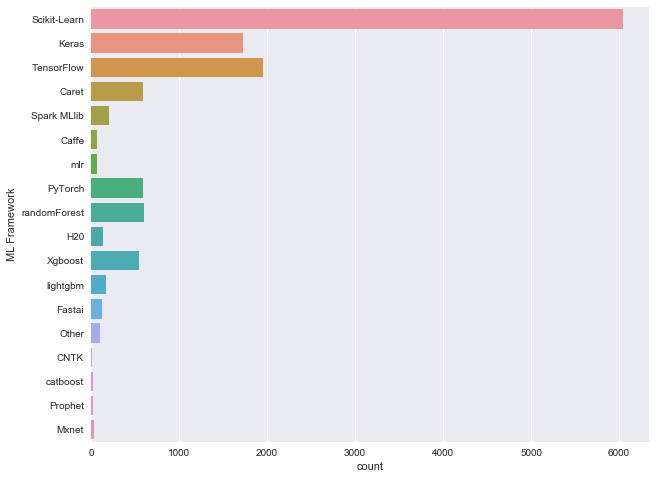

```python
generate_horizontal_countplot(y=frequentMLDF.frequent_ml,
                             figSize=(10,8),
                             ylabel = 'ML Framework',
                             figName = 'Frequent_ML_Framework.jpeg')
```

We will persist the clean copy of the dataframe as a CSV file.

We no longer need "frequentMLDF" in the analysis. We will clean up from memory.

```python
frequentMLDF.to_csv('frequentML.csv',index=False)
```

```python
del frequentMLDF
gc.collect()
```

```
3901
```

### What data visualization libraries or tools have you used in the past 5 years?

- **ggplot2**
- **Matplotlib**
- **Altair**
- **Shiny**
- **D3**
- **Plotly**
- **Bokeh**
- **Seaborn**
- **Geoplotlib**
- **Leaflet**
- **Lattice**
- **None**
- **Other**

```python
visualizationDF = multipleChoiceDF[['Q21_Part_1', 'Q21_Part_2','Q21_Part_3', 'Q21_Part_4','Q21_Part_5', 'Q21_Part_6',
                                    'Q21_Part_7','Q21_Part_8','Q21_Part_9','Q21_Part_10','Q21_Part_11','Q21_Part_12',
                                    'Q21_Part_13']]
```

```python
visualizationDF.head()
```

|  | Q21_Part_1 | Q21_Part_2 | Q21_Part_3 | Q21_Part_4 | Q21_Part_5 | Q21_Part_6 | Q21_Part_7 | Q21_Part_8 | Q21_Part_9 | Q21_Part_10 | Q21_Part_11 | Q21_Part_12 | Q21_Part_13 |
| --- | --- | --- | --- | --- | --- | --- | --- | --- | --- | --- | --- | --- | --- |
| 0 | What data visualization libraries or tools hav... | What data visualization libraries or tools hav... | What data visualization libraries or tools hav... | What data visualization libraries or tools hav... | What data visualization libraries or tools hav... | What data visualization libraries or tools hav... | What data visualization libraries or tools hav... | What data visualization libraries or tools hav... | What data visualization libraries or tools hav... | What data visualization libraries or tools hav... | What data visualization libraries or tools hav... | What data visualization libraries or tools hav... | What data visualization libraries or tools hav... |
| 1 | NaN | Matplotlib | NaN | NaN | NaN | NaN | NaN | NaN | NaN | NaN | NaN | NaN | NaN |
| 2 | NaN | NaN | NaN | NaN | NaN | NaN | NaN | NaN | NaN | NaN | NaN | None | NaN |
| 3 | ggplot2 | Matplotlib | NaN | NaN | NaN | NaN | NaN | Seaborn | NaN | NaN | NaN | NaN | NaN |
| 4 | ggplot2 | Matplotlib | Altair | Shiny | D3 | NaN | Bokeh | Seaborn | NaN | NaN | Lattice | NaN | NaN |

```python
visualizationDF.info()
```

```
<class 'pandas.core.frame.DataFrame'>
RangeIndex: 23860 entries, 0 to 23859
Data columns (total 13 columns):
Q21_Part_1     7752 non-null object
Q21_Part_2     13393 non-null object
Q21_Part_3     220 non-null object
Q21_Part_4     2629 non-null object
Q21_Part_5     2220 non-null object
Q21_Part_6     5598 non-null object
Q21_Part_7     1908 non-null object
Q21_Part_8     7776 non-null object
Q21_Part_9     769 non-null object
Q21_Part_10    1014 non-null object
Q21_Part_11    873 non-null object
Q21_Part_12    1922 non-null object
Q21_Part_13    586 non-null object
dtypes: object(13)
memory usage: 2.4+ MB
```

From the visual and programmatic analysis:

- There are rows with missing data, but deviating from data we explored till now, missing information is expected per record as selections are optional. We will melt into one single column removing missing values, and use this column for analysis.
- All columns are loaded with the correct data type.
- Row with ID 0, is the same as the question. We will drop this row from the analysis as it does not have any empirical value.
- Column names are not informative, we will rename columns with more informative names.

```python
visualizationDF.drop([0],inplace=True)
```

```python
visualizationDF.reset_index(drop=True,inplace=True)
```

```python
visualizationDF = pd.melt(visualizationDF)
```

```python
visualizationDF.head()
```

|  | variable | value |
| --- | --- | --- |
| 0 | Q21_Part_1 | NaN |
| 1 | Q21_Part_1 | NaN |
| 2 | Q21_Part_1 | ggplot2 |
| 3 | Q21_Part_1 | ggplot2 |
| 4 | Q21_Part_1 | NaN |

```python
visualizationDF.drop(columns=['variable'],inplace=True)
visualizationDF.rename(columns={'value':'visualization_tool'},inplace=True)
visualizationDF.dropna(inplace=True)
visualizationDF.reset_index(drop=True,inplace=True)
```

```python
visualizationDF.head()
```

|  | visualization_tool |
| --- | --- |
| 0 | ggplot2 |
| 1 | ggplot2 |
| 2 | ggplot2 |
| 3 | ggplot2 |
| 4 | ggplot2 |

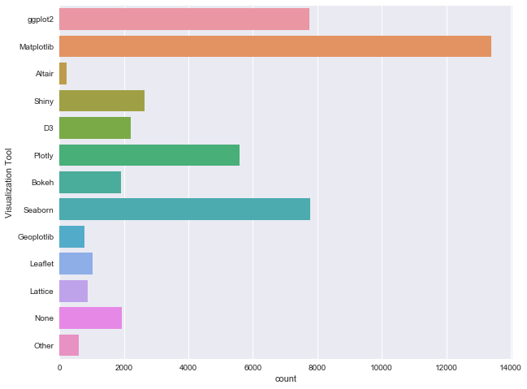

```python
generate_horizontal_countplot(y=visualizationDF.visualization_tool,
                             figSize=(10,8),
                             ylabel = 'Visualization Tool',
                             figName = 'visualization_tool.jpeg')
```

We will persist the clean copy of the dataframe as a CSV file.

We no longer need "visualizationDF" in the analysis. We will clean up from memory.

```python
visualizationDF.to_csv('visualization.csv',index=False)
```

```python
del visualizationDF
gc.collect()
```

```
3404
```

### Which specific data visualization library or tool have you used the most?

```python
frequentVisualizationDF = pd.DataFrame(multipleChoiceDF.Q22)
```

```python
frequentVisualizationDF.head()
```

|  | Q22 |
| --- | --- |
| 0 | Of the choices that you selected in the previo... |
| 1 | NaN |
| 2 | NaN |
| 3 | ggplot2 |
| 4 | ggplot2 |

```python
frequentVisualizationDF.info()
```

```
<class 'pandas.core.frame.DataFrame'>
RangeIndex: 23860 entries, 0 to 23859
Data columns (total 1 columns):
Q22    12185 non-null object
dtypes: object(1)
memory usage: 186.5+ KB
```

From the visual and programmatic analysis:

- There are rows with missing data, we will not include these records in our report.
- All columns are loaded with the correct data type.
- Row with ID 0, is the same as the question. We will drop this row from the analysis as it does not have any empirical value.
- Column names are not informative, we will rename columns with more informative names.

```python
frequentVisualizationDF.drop([0],inplace=True)
frequentVisualizationDF.dropna(inplace=True)
frequentVisualizationDF.reset_index(drop=True,inplace=True)
```

```python
frequentVisualizationDF.rename(columns={"Q22":"visualization_tool"},inplace=True)
```

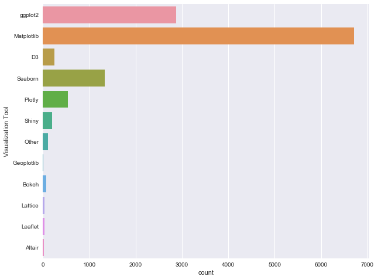

```python
generate_horizontal_countplot(y=frequentVisualizationDF.visualization_tool,
                             figSize=(10,8),
                             ylabel = 'Visualization Tool',
                             figName = 'frequent_visualization_tool.jpeg')
```

We will persist the clean copy of the dataframe as a CSV file.

We no longer need "frequentVisualizationDF" in the analysis. We will clean up from memory.

```python
frequentVisualizationDF.to_csv('frequentVisualization.csv',index=False)
```

```python
del frequentVisualizationDF
gc.collect()
```

```
3287
```

### Which of the following cloud computing products have you used at work or school in the last 5 years?

- **AWS Elastic Compute Cloud (EC2)**
- **Google Compute Engine**
- **AWS Elastic Beanstalk**
- **Google App Engine**
- **Google Kubernetes Engine**
- **AWS Lambda**
- **Google Cloud Functions**
- **AWS Batch**
- **Azure Virtual Machines**
- **Azure Container Service**
- **Azure Functions**
- **Azure Event Grid**
- **Azure Batch**
- **Azure Kubernetes Service**
- **IBM Cloud Virtual Servers**
- **IBM Cloud Container Registry**
- **IBM Cloud Kubernetes Service**
- **IBM Cloud Foundry**
- **None**
- **Other**

```python
cloudProductsDF = multipleChoiceDF[['Q27_Part_1', 'Q27_Part_2','Q27_Part_3', 'Q27_Part_4','Q27_Part_5', 'Q27_Part_6',
                                  'Q27_Part_7','Q27_Part_8','Q27_Part_9','Q27_Part_10','Q27_Part_11','Q27_Part_12',
                                  'Q27_Part_13','Q27_Part_14','Q27_Part_15','Q27_Part_16','Q27_Part_17','Q27_Part_18',
                                  'Q27_Part_19','Q27_Part_20']]
```

```python
cloudProductsDF.head()
```

|  | Q27_Part_1 | Q27_Part_2 | Q27_Part_3 | Q27_Part_4 | Q27_Part_5 | Q27_Part_6 | Q27_Part_7 | Q27_Part_8 | Q27_Part_9 | Q27_Part_10 | Q27_Part_11 | Q27_Part_12 | Q27_Part_13 | Q27_Part_14 | Q27_Part_15 | Q27_Part_16 | Q27_Part_17 | Q27_Part_18 | Q27_Part_19 | Q27_Part_20 |
| --- | --- | --- | --- | --- | --- | --- | --- | --- | --- | --- | --- | --- | --- | --- | --- | --- | --- | --- | --- | --- |
| 0 | Which of the following cloud computing product... | Which of the following cloud computing product... | Which of the following cloud computing product... | Which of the following cloud computing product... | Which of the following cloud computing product... | Which of the following cloud computing product... | Which of the following cloud computing product... | Which of the following cloud computing product... | Which of the following cloud computing product... | Which of the following cloud computing product... | Which of the following cloud computing product... | Which of the following cloud computing product... | Which of the following cloud computing product... | Which of the following cloud computing product... | Which of the following cloud computing product... | Which of the following cloud computing product... | Which of the following cloud computing product... | Which of the following cloud computing product... | Which of the following cloud computing product... | Which of the following cloud computing product... |
| 1 | NaN | NaN | NaN | NaN | NaN | NaN | NaN | NaN | NaN | NaN | NaN | NaN | NaN | NaN | NaN | NaN | NaN | NaN | None | NaN |
| 2 | NaN | NaN | NaN | NaN | NaN | NaN | NaN | NaN | NaN | NaN | NaN | NaN | NaN | NaN | NaN | NaN | NaN | NaN | NaN | NaN |
| 3 | NaN | NaN | NaN | NaN | NaN | NaN | NaN | NaN | NaN | NaN | NaN | NaN | NaN | NaN | NaN | NaN | NaN | NaN | NaN | NaN |
| 4 | NaN | NaN | NaN | NaN | NaN | NaN | NaN | NaN | NaN | NaN | NaN | NaN | NaN | NaN | NaN | NaN | NaN | NaN | NaN | NaN |

```python
cloudProductsDF.info()
```

```
<class 'pandas.core.frame.DataFrame'>
RangeIndex: 23860 entries, 0 to 23859
Data columns (total 20 columns):
Q27_Part_1     3873 non-null object
Q27_Part_2     2206 non-null object
Q27_Part_3     767 non-null object
Q27_Part_4     1383 non-null object
Q27_Part_5     617 non-null object
Q27_Part_6     1692 non-null object
Q27_Part_7     1200 non-null object
Q27_Part_8     496 non-null object
Q27_Part_9     1457 non-null object
Q27_Part_10    473 non-null object
Q27_Part_11    556 non-null object
Q27_Part_12    120 non-null object
Q27_Part_13    232 non-null object
Q27_Part_14    237 non-null object
Q27_Part_15    346 non-null object
Q27_Part_16    165 non-null object
Q27_Part_17    159 non-null object
Q27_Part_18    323 non-null object
Q27_Part_19    3377 non-null object
Q27_Part_20    390 non-null object
dtypes: object(20)
memory usage: 3.6+ MB
```

From the visual and programmatic analysis:

- There are rows with missing data, but deviating from data we explored till now, missing information is expected per record as selections are optional. We will melt into one single column removing missing values, and use this column for analysis.
- All columns are loaded with the correct data type.
- Row with ID 0, is the same as the question. We will drop this row from the analysis as it does not have any empirical value.
- Column names are not informative, we will rename columns with more informative names.

```python
cloudProductsDF.drop([0],inplace=True)
cloudProductsDF.reset_index(drop=True,inplace=True)
```

```python
cloudProductsDF.head()
```

|  | Q27_Part_1 | Q27_Part_2 | Q27_Part_3 | Q27_Part_4 | Q27_Part_5 | Q27_Part_6 | Q27_Part_7 | Q27_Part_8 | Q27_Part_9 | Q27_Part_10 | Q27_Part_11 | Q27_Part_12 | Q27_Part_13 | Q27_Part_14 | Q27_Part_15 | Q27_Part_16 | Q27_Part_17 | Q27_Part_18 | Q27_Part_19 | Q27_Part_20 |
| --- | --- | --- | --- | --- | --- | --- | --- | --- | --- | --- | --- | --- | --- | --- | --- | --- | --- | --- | --- | --- |
| 0 | NaN | NaN | NaN | NaN | NaN | NaN | NaN | NaN | NaN | NaN | NaN | NaN | NaN | NaN | NaN | NaN | NaN | NaN | None | NaN |
| 1 | NaN | NaN | NaN | NaN | NaN | NaN | NaN | NaN | NaN | NaN | NaN | NaN | NaN | NaN | NaN | NaN | NaN | NaN | NaN | NaN |
| 2 | NaN | NaN | NaN | NaN | NaN | NaN | NaN | NaN | NaN | NaN | NaN | NaN | NaN | NaN | NaN | NaN | NaN | NaN | NaN | NaN |
| 3 | NaN | NaN | NaN | NaN | NaN | NaN | NaN | NaN | NaN | NaN | NaN | NaN | NaN | NaN | NaN | NaN | NaN | NaN | NaN | NaN |
| 4 | NaN | NaN | NaN | NaN | Google Kubernetes Engine | NaN | NaN | NaN | NaN | NaN | NaN | NaN | NaN | NaN | NaN | NaN | NaN | NaN | NaN | NaN |

```python
cloudProductsDF.info()
```

```
<class 'pandas.core.frame.DataFrame'>
RangeIndex: 23859 entries, 0 to 23858
Data columns (total 20 columns):
Q27_Part_1     3872 non-null object
Q27_Part_2     2205 non-null object
Q27_Part_3     766 non-null object
Q27_Part_4     1382 non-null object
Q27_Part_5     616 non-null object
Q27_Part_6     1691 non-null object
Q27_Part_7     1199 non-null object
Q27_Part_8     495 non-null object
Q27_Part_9     1456 non-null object
Q27_Part_10    472 non-null object
Q27_Part_11    555 non-null object
Q27_Part_12    119 non-null object
Q27_Part_13    231 non-null object
Q27_Part_14    236 non-null object
Q27_Part_15    345 non-null object
Q27_Part_16    164 non-null object
Q27_Part_17    158 non-null object
Q27_Part_18    322 non-null object
Q27_Part_19    3376 non-null object
Q27_Part_20    389 non-null object
dtypes: object(20)
memory usage: 3.6+ MB
```

```python
cloudProductsDF = pd.melt(cloudProductsDF)
```

```python
cloudProductsDF.head()
```

|  | variable | value |
| --- | --- | --- |
| 0 | Q27_Part_1 | NaN |
| 1 | Q27_Part_1 | NaN |
| 2 | Q27_Part_1 | NaN |
| 3 | Q27_Part_1 | NaN |
| 4 | Q27_Part_1 | NaN |

```python
cloudProductsDF.drop(columns=['variable'],inplace=True)
```

```python
cloudProductsDF.head()
```

|  | value |
| --- | --- |
| 0 | NaN |
| 1 | NaN |
| 2 | NaN |
| 3 | NaN |
| 4 | NaN |

```python
cloudProductsDF.dropna(inplace=True)
cloudProductsDF.reset_index(drop=True,inplace=True)
```

```python
cloudProductsDF.head()
```

|  | value |
| --- | --- |
| 0 | AWS Elastic Compute Cloud (EC2) |
| 1 | AWS Elastic Compute Cloud (EC2) |
| 2 | AWS Elastic Compute Cloud (EC2) |
| 3 | AWS Elastic Compute Cloud (EC2) |
| 4 | AWS Elastic Compute Cloud (EC2) |

```python
cloudProductsDF.rename(columns={"value":"cloudProducts"},inplace=True)
```

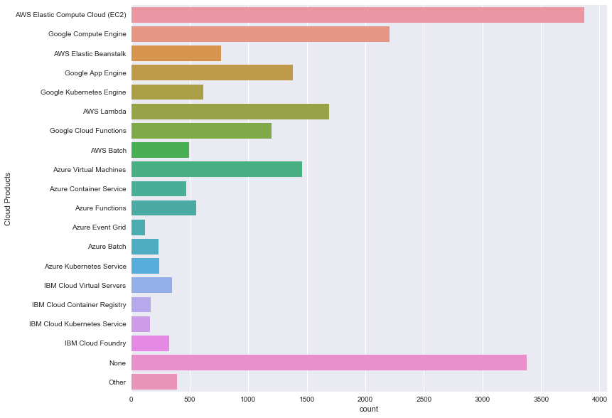

```python
generate_horizontal_countplot(y=cloudProductsDF.cloudProducts,
                             ylabel = 'Cloud Products',
                             figName = 'cloudProducts.jpeg')
```

We will persist the clean copy of the dataframe as a CSV file.

We no longer need "cloudProductsDF" in the analysis. We will clean up from memory.

```python
cloudProductsDF.to_csv('cloudProducts.csv',index=False)
```

```python
del cloudProductsDF
gc.collect()
```

```
4435
```

### Which of the following machine learning products have you used at work or school in the last 5 years?

- **Amazon Transcribe**
- **Google Cloud Speech-to-text API**
- **Amazon Rekognition**
- **Google Cloud Vision API**
- **Amazon Comprehend**
- **Google Cloud Natural Language API**
- **Amazon Translate**
- **Google Cloud Translation API**
- **Amazon Lex**
- **Google Dialogflow Enterprise Edition**
- **Amazon Rekognition Video**
- **Google Cloud Video Intelligence API**
- **Google Cloud AutoML**
- **Amazon SageMaker**
- **Google Cloud Machine Learning Engine**
- **DataRobot**
- **H20 Driverless AI**
- **Domino Datalab**
- **SAS**
- **Dataiku**
- **RapidMiner**
- **Instabase**
- **Algorithmia**
- **Dataversity**
- **Cloudera**
- **Azure Machine Learning Studio**
- **Azure Machine Learning Workbench**
- **Azure Cortana Intelligence Suite**
- **Azure Bing Speech API**
- **Azure Speaker Recognition API**
- **Azure Computer Vision API**
- **Azure Face API**
- **Azure Video API**
- **IBM Watson Studio**
- **IBM Watson Knowledge Catalog**
- **IBM Watson Assistant**
- **IBM Watson Discovery**
- **IBM Watson Text to Speech**
- **IBM Watson Visual Recognition**
- **IBM Watson Machine Learning**
- **Azure Cognitive Services**
- **None**
- **Other**

```python
mlProductsDF = multipleChoiceDF[['Q28_Part_1', 'Q28_Part_2','Q28_Part_3', 'Q28_Part_4','Q28_Part_5', 'Q28_Part_6',
                                 'Q28_Part_7','Q28_Part_8','Q28_Part_9','Q28_Part_10','Q28_Part_11','Q28_Part_12',
                                 'Q28_Part_13','Q28_Part_14','Q28_Part_15','Q28_Part_16','Q28_Part_17','Q28_Part_18',
                                 'Q28_Part_19','Q28_Part_20','Q28_Part_21', 'Q28_Part_22','Q28_Part_23', 'Q28_Part_24',
                                 'Q28_Part_25', 'Q28_Part_26','Q28_Part_27','Q28_Part_28','Q28_Part_29','Q28_Part_30',
                                 'Q28_Part_31','Q28_Part_32','Q28_Part_33','Q28_Part_34','Q28_Part_35','Q28_Part_36',
                                 'Q28_Part_37','Q28_Part_38','Q28_Part_39','Q28_Part_40','Q28_Part_41','Q28_Part_42',
                                 'Q28_Part_43']]
```

```python
mlProductsDF.head()
```

|  | Q28_Part_1 | Q28_Part_2 | Q28_Part_3 | Q28_Part_4 | Q28_Part_5 | Q28_Part_6 | Q28_Part_7 | Q28_Part_8 | Q28_Part_9 | Q28_Part_10 | ... | Q28_Part_34 | Q28_Part_35 | Q28_Part_36 | Q28_Part_37 | Q28_Part_38 | Q28_Part_39 | Q28_Part_40 | Q28_Part_41 | Q28_Part_42 | Q28_Part_43 |
| --- | --- | --- | --- | --- | --- | --- | --- | --- | --- | --- | --- | --- | --- | --- | --- | --- | --- | --- | --- | --- | --- |
| 0 | Which of the following machine learning produc... | Which of the following machine learning produc... | Which of the following machine learning produc... | Which of the following machine learning produc... | Which of the following machine learning produc... | Which of the following machine learning produc... | Which of the following machine learning produc... | Which of the following machine learning produc... | Which of the following machine learning produc... | Which of the following machine learning produc... | ... | Which of the following machine learning produc... | Which of the following machine learning produc... | Which of the following machine learning produc... | Which of the following machine learning produc... | Which of the following machine learning produc... | Which of the following machine learning produc... | Which of the following machine learning produc... | Which of the following machine learning produc... | Which of the following machine learning produc... | Which of the following machine learning produc... |
| 1 | NaN | NaN | NaN | NaN | NaN | NaN | NaN | NaN | NaN | NaN | ... | NaN | NaN | NaN | NaN | NaN | NaN | NaN | NaN | NaN | NaN |
| 2 | NaN | NaN | NaN | NaN | NaN | NaN | NaN | NaN | NaN | NaN | ... | NaN | NaN | NaN | NaN | NaN | NaN | NaN | NaN | NaN | NaN |
| 3 | NaN | NaN | NaN | NaN | NaN | NaN | NaN | NaN | NaN | NaN | ... | NaN | NaN | NaN | NaN | NaN | NaN | NaN | NaN | NaN | NaN |
| 4 | NaN | NaN | NaN | NaN | NaN | NaN | NaN | NaN | NaN | NaN | ... | NaN | NaN | NaN | NaN | NaN | NaN | NaN | NaN | NaN | NaN |

5 rows × 43 columns

```python
mlProductsDF.info()
```

```
<class 'pandas.core.frame.DataFrame'>
RangeIndex: 23860 entries, 0 to 23859
Data columns (total 43 columns):
Q28_Part_1     119 non-null object
Q28_Part_2     625 non-null object
Q28_Part_3     300 non-null object
Q28_Part_4     665 non-null object
Q28_Part_5     133 non-null object
Q28_Part_6     623 non-null object
Q28_Part_7     161 non-null object
Q28_Part_8     531 non-null object
Q28_Part_9     210 non-null object
Q28_Part_10    173 non-null object
Q28_Part_11    131 non-null object
Q28_Part_12    175 non-null object
Q28_Part_13    433 non-null object
Q28_Part_14    487 non-null object
Q28_Part_15    666 non-null object
Q28_Part_16    251 non-null object
Q28_Part_17    284 non-null object
Q28_Part_18    85 non-null object
Q28_Part_19    859 non-null object
Q28_Part_20    224 non-null object
Q28_Part_21    625 non-null object
Q28_Part_22    18 non-null object
Q28_Part_23    120 non-null object
Q28_Part_24    32 non-null object
Q28_Part_25    811 non-null object
Q28_Part_26    759 non-null object
Q28_Part_27    460 non-null object
Q28_Part_28    160 non-null object
Q28_Part_29    130 non-null object
Q28_Part_30    118 non-null object
Q28_Part_31    260 non-null object
Q28_Part_32    185 non-null object
Q28_Part_33    89 non-null object
Q28_Part_34    462 non-null object
Q28_Part_35    197 non-null object
Q28_Part_36    330 non-null object
Q28_Part_37    249 non-null object
Q28_Part_38    296 non-null object
Q28_Part_39    213 non-null object
Q28_Part_40    490 non-null object
Q28_Part_41    334 non-null object
Q28_Part_42    5371 non-null object
Q28_Part_43    260 non-null object
dtypes: object(43)
memory usage: 7.8+ MB
```

From the visual and programmatic analysis:

- There are rows with missing data, but deviating from data we explored till now, missing information is expected per record as selections are optional. We will melt into one single column removing missing values, and use this column for analysis.
- All columns are loaded with the correct data type.
- Row with ID 0, is the same as the question. We will drop this row from the analysis as it does not have any empirical value.
- Column names are not informative, we will rename columns with more informative names.

```python
mlProductsDF.drop([0],inplace=True)
mlProductsDF.reset_index(drop=True,inplace=True)
```

```python
mlProductsDF.head()
```

|  | Q28_Part_1 | Q28_Part_2 | Q28_Part_3 | Q28_Part_4 | Q28_Part_5 | Q28_Part_6 | Q28_Part_7 | Q28_Part_8 | Q28_Part_9 | Q28_Part_10 | ... | Q28_Part_34 | Q28_Part_35 | Q28_Part_36 | Q28_Part_37 | Q28_Part_38 | Q28_Part_39 | Q28_Part_40 | Q28_Part_41 | Q28_Part_42 | Q28_Part_43 |
| --- | --- | --- | --- | --- | --- | --- | --- | --- | --- | --- | --- | --- | --- | --- | --- | --- | --- | --- | --- | --- | --- |
| 0 | NaN | NaN | NaN | NaN | NaN | NaN | NaN | NaN | NaN | NaN | ... | NaN | NaN | NaN | NaN | NaN | NaN | NaN | NaN | NaN | NaN |
| 1 | NaN | NaN | NaN | NaN | NaN | NaN | NaN | NaN | NaN | NaN | ... | NaN | NaN | NaN | NaN | NaN | NaN | NaN | NaN | NaN | NaN |
| 2 | NaN | NaN | NaN | NaN | NaN | NaN | NaN | NaN | NaN | NaN | ... | NaN | NaN | NaN | NaN | NaN | NaN | NaN | NaN | NaN | NaN |
| 3 | NaN | NaN | NaN | NaN | NaN | NaN | NaN | NaN | NaN | NaN | ... | NaN | NaN | NaN | NaN | NaN | NaN | NaN | NaN | NaN | NaN |
| 4 | NaN | NaN | NaN | NaN | NaN | NaN | NaN | Google Cloud Translation API | NaN | NaN | ... | NaN | NaN | NaN | NaN | NaN | NaN | NaN | NaN | NaN | NaN |

5 rows × 43 columns

```python
mlProductsDF = pd.melt(mlProductsDF)
```

```python
mlProductsDF.head()
```

|  | variable | value |
| --- | --- | --- |
| 0 | Q28_Part_1 | NaN |
| 1 | Q28_Part_1 | NaN |
| 2 | Q28_Part_1 | NaN |
| 3 | Q28_Part_1 | NaN |
| 4 | Q28_Part_1 | NaN |

```python
mlProductsDF.drop(columns=['variable'],inplace=True)
mlProductsDF.dropna(inplace=True)
mlProductsDF.reset_index(drop=True,inplace=True)
```

```python
mlProductsDF.head()
```

|  | value |
| --- | --- |
| 0 | Amazon Transcribe |
| 1 | Amazon Transcribe |
| 2 | Amazon Transcribe |
| 3 | Amazon Transcribe |
| 4 | Amazon Transcribe |

```python
mlProductsDF.rename(columns={'value':'mlProducts'},inplace=True)
```

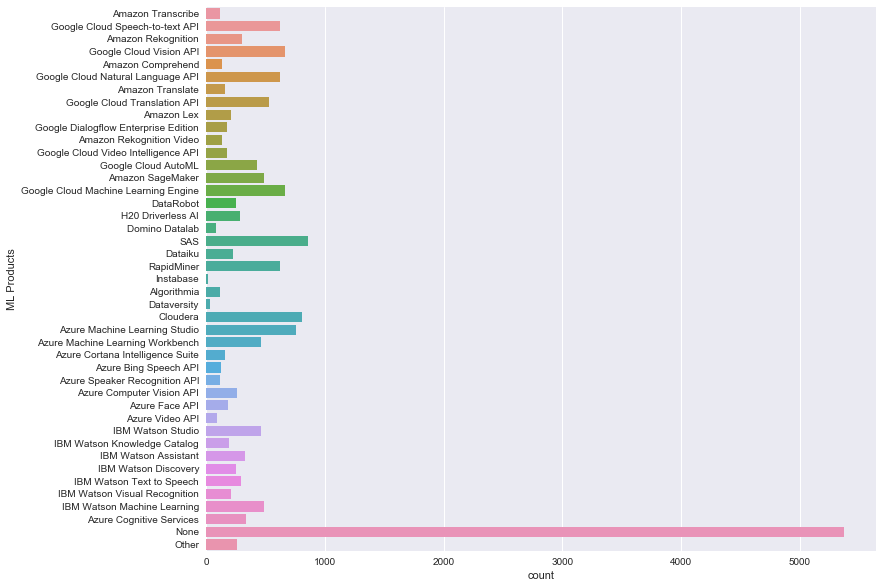

```python
generate_horizontal_countplot(y=mlProductsDF.mlProducts,
                             ylabel = 'ML Products',
                             figName = 'mlProducts.jpeg')
```

We will persist the clean copy of the dataframe as a CSV file.

We no longer need "mlProductsDF" in the analysis. We will clean up from memory.

```python
mlProductsDF.to_csv('mlProducts.csv',index=False)
```

```python
del mlProductsDF
gc.collect()
```

```
7299
```

### Which of the following relational database products have you used at work or school in the last 5 years?

- **AWS Relational Database Service**
- **AWS Aurora**
- **Google Cloud SQL**
- **Google Cloud Spanner**
- **AWS DynamoDB**
- **Google Cloud Datastore**
- **Google Cloud Bigtable**
- **AWS SimpleDB**
- **Microsoft SQL Server**
- **MySQL**
- **PostgresSQL**
- **SQLite**
- **Oracle Database**
- **Ingres**
- **Microsoft Access**
- **NexusDB**
- **SAP IQ**
- **Google Fusion Tables**
- **Azure Database for MySQL**
- **Azure Cosmos DB**
- **Azure SQL Database**
- **Azure Database for PostgreSQL**
- **IBM Cloud Compose**
- **IBM Cloud Compose for MySQL**
- **IBM Cloud Compose for PostgreSQL**
- **IBM Cloud Db2**
- **None**
- **Other**

```python
rdbmsDF = multipleChoiceDF[['Q29_Part_1', 'Q29_Part_2','Q29_Part_3', 'Q29_Part_4','Q29_Part_5', 'Q29_Part_6',
                            'Q29_Part_7','Q29_Part_8','Q29_Part_9','Q29_Part_10','Q29_Part_11','Q29_Part_12',
                            'Q29_Part_13','Q29_Part_14','Q29_Part_15','Q29_Part_16','Q29_Part_17','Q29_Part_18',
                            'Q29_Part_19','Q29_Part_20','Q29_Part_21', 'Q29_Part_22','Q29_Part_23', 'Q29_Part_24',
                            'Q29_Part_25', 'Q29_Part_26','Q29_Part_27','Q29_Part_28']]
```

```python
rdbmsDF.head()
```

|  | Q29_Part_1 | Q29_Part_2 | Q29_Part_3 | Q29_Part_4 | Q29_Part_5 | Q29_Part_6 | Q29_Part_7 | Q29_Part_8 | Q29_Part_9 | Q29_Part_10 | ... | Q29_Part_19 | Q29_Part_20 | Q29_Part_21 | Q29_Part_22 | Q29_Part_23 | Q29_Part_24 | Q29_Part_25 | Q29_Part_26 | Q29_Part_27 | Q29_Part_28 |
| --- | --- | --- | --- | --- | --- | --- | --- | --- | --- | --- | --- | --- | --- | --- | --- | --- | --- | --- | --- | --- | --- |
| 0 | Which of the following relational database pro... | Which of the following relational database pro... | Which of the following relational database pro... | Which of the following relational database pro... | Which of the following relational database pro... | Which of the following relational database pro... | Which of the following relational database pro... | Which of the following relational database pro... | Which of the following relational database pro... | Which of the following relational database pro... | ... | Which of the following relational database pro... | Which of the following relational database pro... | Which of the following relational database pro... | Which of the following relational database pro... | Which of the following relational database pro... | Which of the following relational database pro... | Which of the following relational database pro... | Which of the following relational database pro... | Which of the following relational database pro... | Which of the following relational database pro... |
| 1 | NaN | NaN | NaN | NaN | NaN | NaN | NaN | NaN | NaN | NaN | ... | NaN | NaN | NaN | NaN | NaN | NaN | NaN | NaN | NaN | NaN |
| 2 | NaN | NaN | NaN | NaN | NaN | NaN | NaN | NaN | NaN | NaN | ... | NaN | NaN | NaN | NaN | NaN | NaN | NaN | NaN | NaN | NaN |
| 3 | NaN | NaN | NaN | NaN | NaN | NaN | NaN | NaN | NaN | NaN | ... | NaN | NaN | NaN | NaN | NaN | NaN | NaN | NaN | NaN | NaN |
| 4 | NaN | NaN | NaN | NaN | NaN | NaN | NaN | NaN | NaN | NaN | ... | NaN | NaN | NaN | NaN | NaN | NaN | NaN | NaN | NaN | NaN |

5 rows × 28 columns

```python
rdbmsDF.info()
```

```
<class 'pandas.core.frame.DataFrame'>
RangeIndex: 23860 entries, 0 to 23859
Data columns (total 28 columns):
Q29_Part_1     899 non-null object
Q29_Part_2     315 non-null object
Q29_Part_3     616 non-null object
Q29_Part_4     104 non-null object
Q29_Part_5     731 non-null object
Q29_Part_6     516 non-null object
Q29_Part_7     514 non-null object
Q29_Part_8     200 non-null object
Q29_Part_9     3125 non-null object
Q29_Part_10    6189 non-null object
Q29_Part_11    3853 non-null object
Q29_Part_12    3730 non-null object
Q29_Part_13    2416 non-null object
Q29_Part_14    60 non-null object
Q29_Part_15    1355 non-null object
Q29_Part_16    39 non-null object
Q29_Part_17    72 non-null object
Q29_Part_18    121 non-null object
Q29_Part_19    253 non-null object
Q29_Part_20    214 non-null object
Q29_Part_21    669 non-null object
Q29_Part_22    138 non-null object
Q29_Part_23    67 non-null object
Q29_Part_24    62 non-null object
Q29_Part_25    54 non-null object
Q29_Part_26    256 non-null object
Q29_Part_27    1363 non-null object
Q29_Part_28    564 non-null object
dtypes: object(28)
memory usage: 5.1+ MB
```

From the visual and programmatic analysis:

- There are rows with missing data, but deviating from data we explored till now, missing information is expected per record as selections are optional. We will melt into one single column removing missing values, and use this column for analysis.
- All columns are loaded with the correct data type.
- Row with ID 0, is the same as the question. We will drop this row from the analysis as it does not have any empirical value.
- Column names are not informative, we will rename columns with more informative names.

```python
rdbmsDF.drop([0],inplace=True)
rdbmsDF.reset_index(drop=True,inplace=True)
```

```python
rdbmsDF.head()
```

|  | Q29_Part_1 | Q29_Part_2 | Q29_Part_3 | Q29_Part_4 | Q29_Part_5 | Q29_Part_6 | Q29_Part_7 | Q29_Part_8 | Q29_Part_9 | Q29_Part_10 | ... | Q29_Part_19 | Q29_Part_20 | Q29_Part_21 | Q29_Part_22 | Q29_Part_23 | Q29_Part_24 | Q29_Part_25 | Q29_Part_26 | Q29_Part_27 | Q29_Part_28 |
| --- | --- | --- | --- | --- | --- | --- | --- | --- | --- | --- | --- | --- | --- | --- | --- | --- | --- | --- | --- | --- | --- |
| 0 | NaN | NaN | NaN | NaN | NaN | NaN | NaN | NaN | NaN | NaN | ... | NaN | NaN | NaN | NaN | NaN | NaN | NaN | NaN | NaN | NaN |
| 1 | NaN | NaN | NaN | NaN | NaN | NaN | NaN | NaN | NaN | NaN | ... | NaN | NaN | NaN | NaN | NaN | NaN | NaN | NaN | NaN | NaN |
| 2 | NaN | NaN | NaN | NaN | NaN | NaN | NaN | NaN | NaN | NaN | ... | NaN | NaN | NaN | NaN | NaN | NaN | NaN | NaN | NaN | NaN |
| 3 | NaN | NaN | NaN | NaN | NaN | NaN | NaN | NaN | NaN | NaN | ... | NaN | NaN | NaN | NaN | NaN | NaN | NaN | NaN | NaN | NaN |
| 4 | NaN | NaN | NaN | NaN | NaN | NaN | NaN | NaN | NaN | NaN | ... | NaN | NaN | NaN | NaN | IBM Cloud Compose | NaN | NaN | NaN | NaN | NaN |

5 rows × 28 columns

```python
rdbmsDF = pd.melt(rdbmsDF)
```

```python
rdbmsDF.head()
```

|  | variable | value |
| --- | --- | --- |
| 0 | Q29_Part_1 | NaN |
| 1 | Q29_Part_1 | NaN |
| 2 | Q29_Part_1 | NaN |
| 3 | Q29_Part_1 | NaN |
| 4 | Q29_Part_1 | NaN |

```python
rdbmsDF.drop(columns=['variable'],inplace=True)
rdbmsDF.dropna(inplace=True)
rdbmsDF.reset_index(drop=True,inplace=True)
```

```python
rdbmsDF.rename(columns={'value':'rdbms'},inplace=True)
```

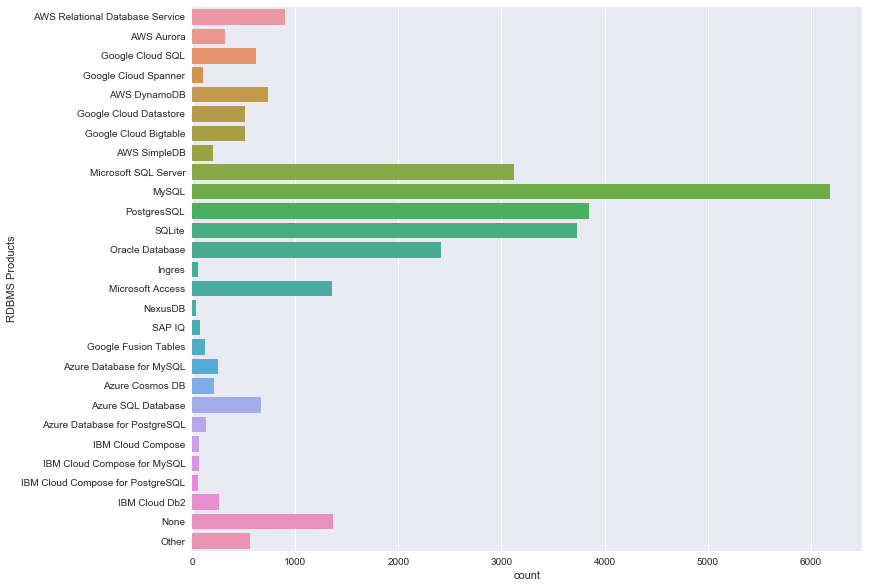

```python
generate_horizontal_countplot(y=rdbmsDF.rdbms,
                             ylabel = 'RDBMS Products',
                             figName = 'rdbmsProducts.jpeg')
```

We will persist the clean copy of the dataframe as a CSV file.

We no longer need "rdbmsDF" in the analysis. We will clean up from memory.

```python
rdbmsDF.to_csv('rdbms.csv',index=False)
```

```python
del rdbmsDF
gc.collect()
```

```
5016
```

### Which of the following big data and analytics products have you used at work or school in the last 5 years?

- **AWS Elastic MapReduce**
- **AWS Batch**
- **Google Cloud Dataproc**
- **Google Cloud Dataflow**
- **Google Cloud Dataprep**
- **AWS Kinesis**
- **Google Cloud Pub/Sub**
- **AWS Athena**
- **AWS Redshift**
- **Google BigQuery**
- **Teradata**
- **Microsoft Analysis Services**
- **Oracle Exadata**
- **Oracle Warehouse Builder**
- **SAP IQ**
- **Snowflake**
- **Databricks**
- **Azure SQL Data Warehouse**
- **Azure HDInsight**
- **Azure Stream Analytics**
- **IBM InfoSphere DataStorage**
- **IBM Cloud Analytics Engine**
- **IBM Cloud Streaming Analytics**
- **None**
- **Other**

```python
bigDataAnalytcsDF = multipleChoiceDF[['Q30_Part_1', 'Q30_Part_2','Q30_Part_3', 'Q30_Part_4','Q30_Part_5',
                                      'Q30_Part_6','Q30_Part_7','Q30_Part_8','Q30_Part_9','Q30_Part_10',
                                      'Q30_Part_11','Q30_Part_12','Q30_Part_13','Q30_Part_14','Q30_Part_15',
                                      'Q30_Part_16','Q30_Part_17','Q30_Part_18','Q30_Part_19','Q30_Part_20',
                                      'Q30_Part_21', 'Q30_Part_22','Q30_Part_23', 'Q30_Part_24','Q30_Part_25']]
```

```python
bigDataAnalytcsDF.head()
```

|  | Q30_Part_1 | Q30_Part_2 | Q30_Part_3 | Q30_Part_4 | Q30_Part_5 | Q30_Part_6 | Q30_Part_7 | Q30_Part_8 | Q30_Part_9 | Q30_Part_10 | ... | Q30_Part_16 | Q30_Part_17 | Q30_Part_18 | Q30_Part_19 | Q30_Part_20 | Q30_Part_21 | Q30_Part_22 | Q30_Part_23 | Q30_Part_24 | Q30_Part_25 |
| --- | --- | --- | --- | --- | --- | --- | --- | --- | --- | --- | --- | --- | --- | --- | --- | --- | --- | --- | --- | --- | --- |
| 0 | Which of the following big data and analytics ... | Which of the following big data and analytics ... | Which of the following big data and analytics ... | Which of the following big data and analytics ... | Which of the following big data and analytics ... | Which of the following big data and analytics ... | Which of the following big data and analytics ... | Which of the following big data and analytics ... | Which of the following big data and analytics ... | Which of the following big data and analytics ... | ... | Which of the following big data and analytics ... | Which of the following big data and analytics ... | Which of the following big data and analytics ... | Which of the following big data and analytics ... | Which of the following big data and analytics ... | Which of the following big data and analytics ... | Which of the following big data and analytics ... | Which of the following big data and analytics ... | Which of the following big data and analytics ... | Which of the following big data and analytics ... |
| 1 | NaN | NaN | NaN | NaN | NaN | NaN | NaN | NaN | NaN | NaN | ... | NaN | NaN | NaN | NaN | NaN | NaN | NaN | NaN | None | NaN |
| 2 | NaN | NaN | NaN | NaN | NaN | NaN | NaN | NaN | NaN | NaN | ... | NaN | NaN | NaN | NaN | NaN | NaN | NaN | NaN | NaN | NaN |
| 3 | NaN | NaN | NaN | NaN | NaN | NaN | NaN | NaN | NaN | NaN | ... | NaN | NaN | NaN | NaN | NaN | NaN | NaN | NaN | NaN | NaN |
| 4 | NaN | NaN | NaN | NaN | NaN | NaN | NaN | NaN | NaN | NaN | ... | NaN | NaN | NaN | NaN | NaN | NaN | NaN | NaN | NaN | NaN |

5 rows × 25 columns

```python
bigDataAnalytcsDF.info()
```

```
<class 'pandas.core.frame.DataFrame'>
RangeIndex: 23860 entries, 0 to 23859
Data columns (total 25 columns):
Q30_Part_1     622 non-null object
Q30_Part_2     213 non-null object
Q30_Part_3     238 non-null object
Q30_Part_4     386 non-null object
Q30_Part_5     213 non-null object
Q30_Part_6     335 non-null object
Q30_Part_7     287 non-null object
Q30_Part_8     384 non-null object
Q30_Part_9     943 non-null object
Q30_Part_10    1206 non-null object
Q30_Part_11    598 non-null object
Q30_Part_12    422 non-null object
Q30_Part_13    212 non-null object
Q30_Part_14    126 non-null object
Q30_Part_15    62 non-null object
Q30_Part_16    240 non-null object
Q30_Part_17    832 non-null object
Q30_Part_18    284 non-null object
Q30_Part_19    240 non-null object
Q30_Part_20    164 non-null object
Q30_Part_21    68 non-null object
Q30_Part_22    142 non-null object
Q30_Part_23    82 non-null object
Q30_Part_24    5390 non-null object
Q30_Part_25    267 non-null object
dtypes: object(25)
memory usage: 4.6+ MB
```

From the visual and programmatic analysis:

- There are rows with missing data, but deviating from data we explored till now, missing information is expected per record as selections are optional. We will melt into one single column removing missing values, and use this column for analysis.
- All columns are loaded with the correct data type.
- Row with ID 0, is the same as the question. We will drop this row from the analysis as it does not have any empirical value.
- Column names are not informative, we will rename columns with more informative names.

```python
bigDataAnalytcsDF.drop([0],inplace=True)
bigDataAnalytcsDF.reset_index(drop=True,inplace=True)
```

```python
bigDataAnalytcsDF.head()
```

|  | Q30_Part_1 | Q30_Part_2 | Q30_Part_3 | Q30_Part_4 | Q30_Part_5 | Q30_Part_6 | Q30_Part_7 | Q30_Part_8 | Q30_Part_9 | Q30_Part_10 | ... | Q30_Part_16 | Q30_Part_17 | Q30_Part_18 | Q30_Part_19 | Q30_Part_20 | Q30_Part_21 | Q30_Part_22 | Q30_Part_23 | Q30_Part_24 | Q30_Part_25 |
| --- | --- | --- | --- | --- | --- | --- | --- | --- | --- | --- | --- | --- | --- | --- | --- | --- | --- | --- | --- | --- | --- |
| 0 | NaN | NaN | NaN | NaN | NaN | NaN | NaN | NaN | NaN | NaN | ... | NaN | NaN | NaN | NaN | NaN | NaN | NaN | NaN | None | NaN |
| 1 | NaN | NaN | NaN | NaN | NaN | NaN | NaN | NaN | NaN | NaN | ... | NaN | NaN | NaN | NaN | NaN | NaN | NaN | NaN | NaN | NaN |
| 2 | NaN | NaN | NaN | NaN | NaN | NaN | NaN | NaN | NaN | NaN | ... | NaN | NaN | NaN | NaN | NaN | NaN | NaN | NaN | NaN | NaN |
| 3 | NaN | NaN | NaN | NaN | NaN | NaN | NaN | NaN | NaN | NaN | ... | NaN | NaN | NaN | NaN | NaN | NaN | NaN | NaN | NaN | NaN |
| 4 | NaN | NaN | NaN | Google Cloud Dataflow | NaN | NaN | NaN | NaN | NaN | NaN | ... | NaN | NaN | NaN | NaN | NaN | NaN | NaN | NaN | NaN | NaN |

5 rows × 25 columns

```python
bigDataAnalytcsDF = pd.melt(bigDataAnalytcsDF)
```

```python
bigDataAnalytcsDF.head()
```

|  | variable | value |
| --- | --- | --- |
| 0 | Q30_Part_1 | NaN |
| 1 | Q30_Part_1 | NaN |
| 2 | Q30_Part_1 | NaN |
| 3 | Q30_Part_1 | NaN |
| 4 | Q30_Part_1 | NaN |

```python
bigDataAnalytcsDF.drop(columns=['variable'],inplace=True)
bigDataAnalytcsDF.dropna(inplace=True)
bigDataAnalytcsDF.reset_index(drop=True,inplace=True)
```

```python
bigDataAnalytcsDF.rename(columns={'value':'bigDataAnalytcs'},inplace=True)
```

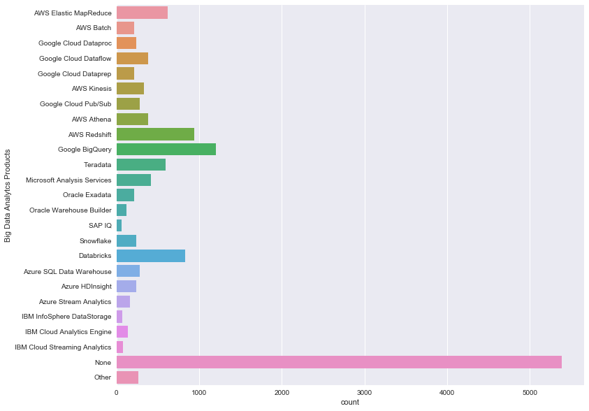

```python
generate_horizontal_countplot(y=bigDataAnalytcsDF.bigDataAnalytcs,
                             ylabel = 'Big Data Analytcs Products',
                             figName = 'bigDataAnalytcs.jpeg')
```

We will persist the clean copy of the dataframe as a CSV file.

We no longer need "bigDataAnalytcsDF" in the analysis. We will clean up from memory.

```python
bigDataAnalytcsDF.to_csv('bigDataAnalytcs.csv',index=False)
```

```python
del bigDataAnalytcsDF
gc.collect()
```

```
4628
```

### Which types of data do you currently interact with most often at work or school?

- **Audio Data**
- **Categorical Data**
- **Genetic Data**
- **Geospatial Data**
- **Image Data**
- **Numerical Data**
- **Sensor Data**
- **Tabular Data**
- **Text Data**
- **Time Series Data**
- **Video Data**
- **Other Data**

```python
dataTypeDF = multipleChoiceDF[['Q31_Part_1', 'Q31_Part_2','Q31_Part_3', 'Q31_Part_4','Q31_Part_5', 'Q31_Part_6',
                               'Q31_Part_7','Q31_Part_8','Q31_Part_9','Q31_Part_10','Q31_Part_11','Q31_Part_12']]
```

```python
dataTypeDF.head()
```

|  | Q31_Part_1 | Q31_Part_2 | Q31_Part_3 | Q31_Part_4 | Q31_Part_5 | Q31_Part_6 | Q31_Part_7 | Q31_Part_8 | Q31_Part_9 | Q31_Part_10 | Q31_Part_11 | Q31_Part_12 |
| --- | --- | --- | --- | --- | --- | --- | --- | --- | --- | --- | --- | --- |
| 0 | Which types of data do you currently interact ... | Which types of data do you currently interact ... | Which types of data do you currently interact ... | Which types of data do you currently interact ... | Which types of data do you currently interact ... | Which types of data do you currently interact ... | Which types of data do you currently interact ... | Which types of data do you currently interact ... | Which types of data do you currently interact ... | Which types of data do you currently interact ... | Which types of data do you currently interact ... | Which types of data do you currently interact ... |
| 1 | NaN | NaN | NaN | NaN | NaN | NaN | NaN | NaN | NaN | NaN | NaN | NaN |
| 2 | NaN | NaN | NaN | NaN | NaN | NaN | NaN | NaN | NaN | NaN | NaN | NaN |
| 3 | NaN | Categorical Data | NaN | NaN | NaN | Numerical Data | NaN | NaN | Text Data | Time Series Data | NaN | NaN |
| 4 | NaN | Categorical Data | NaN | Geospatial Data | NaN | Numerical Data | NaN | Tabular Data | Text Data | Time Series Data | NaN | NaN |

```python
dataTypeDF.info()
```

```
<class 'pandas.core.frame.DataFrame'>
RangeIndex: 23860 entries, 0 to 23859
Data columns (total 12 columns):
Q31_Part_1     954 non-null object
Q31_Part_2     8150 non-null object
Q31_Part_3     1055 non-null object
Q31_Part_4     2246 non-null object
Q31_Part_5     5388 non-null object
Q31_Part_6     11025 non-null object
Q31_Part_7     2553 non-null object
Q31_Part_8     7395 non-null object
Q31_Part_9     8730 non-null object
Q31_Part_10    7780 non-null object
Q31_Part_11    1384 non-null object
Q31_Part_12    406 non-null object
dtypes: object(12)
memory usage: 2.2+ MB
```

From the visual and programmatic analysis:

- There are rows with missing data, but deviating from data we explored till now, missing information is expected per record as selections are optional. We will melt into one single column removing missing values, and use this column for analysis.
- All columns are loaded with the correct data type.
- Row with ID 0, is the same as the question. We will drop this row from the analysis as it does not have any empirical value.
- Column names are not informative, we will rename columns with more informative names.

```python
dataTypeDF.drop([0],inplace=True)
dataTypeDF.reset_index(drop=True,inplace=True)
```

```python
dataTypeDF = pd.melt(dataTypeDF)
```

```python
dataTypeDF.head()
```

|  | variable | value |
| --- | --- | --- |
| 0 | Q31_Part_1 | NaN |
| 1 | Q31_Part_1 | NaN |
| 2 | Q31_Part_1 | NaN |
| 3 | Q31_Part_1 | NaN |
| 4 | Q31_Part_1 | NaN |

```python
dataTypeDF.drop(columns=['variable'],inplace=True)
dataTypeDF.dropna(inplace=True)
dataTypeDF.reset_index(drop=True,inplace=True)
```

```python
dataTypeDF.rename(columns={'value':'dataType'},inplace=True)
```

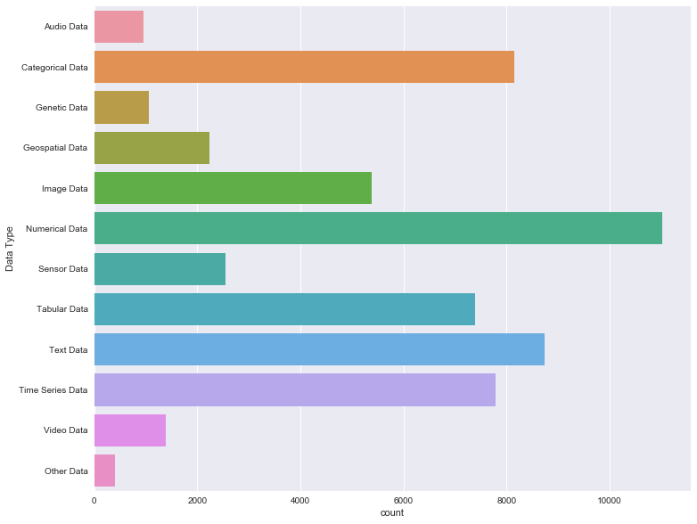

```python
generate_horizontal_countplot(y=dataTypeDF.dataType,
                             ylabel = 'Data Type',
                             figName = 'dataType.jpeg')
```

We will persist the clean copy of the dataframe as a CSV file.

We no longer need "dataTypeDF" in the analysis. We will clean up from memory.

```python
dataTypeDF.to_csv('dataType.csv',index=False)
```

```python
del dataTypeDF
gc.collect()
```

```
3150
```

### What is the type of data that you currently interact with most often at work or school?

```python
frequentDataTypeDF = pd.DataFrame(multipleChoiceDF.Q32)
```

```python
frequentDataTypeDF.head()
```

|  | Q32 |
| --- | --- |
| 0 | What is the type of data that you currently in... |
| 1 | NaN |
| 2 | NaN |
| 3 | Time Series Data |
| 4 | Numerical Data |

```python
frequentDataTypeDF.info()
```

```
<class 'pandas.core.frame.DataFrame'>
RangeIndex: 23860 entries, 0 to 23859
Data columns (total 1 columns):
Q32    13879 non-null object
dtypes: object(1)
memory usage: 186.5+ KB
```

From the visual and programmatic analysis:

- There are rows with missing data, we will not include these records in our report.
- All columns are loaded with the correct data type.
- Row with ID 0, is the same as the question. We will drop this row from the analysis as it does not have any empirical value.
- Column names are not informative, we will rename columns with more informative names.

```python
frequentDataTypeDF.drop([0],inplace=True)
frequentDataTypeDF.dropna(inplace=True)
frequentDataTypeDF.reset_index(drop=True,inplace=True)
```

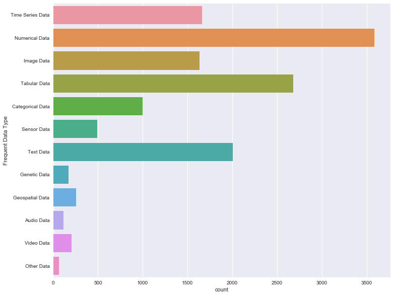

```python
generate_horizontal_countplot(y=frequentDataTypeDF.Q32,
                             ylabel = 'Frequent Data Type',
                             figName = 'frequentDataType.jpeg')
```

We will persist the clean copy of the dataframe as a CSV file.

We no longer need "frequentDataTypeDF" in the analysis. We will clean up from memory.

```python
frequentDataTypeDF.to_csv('frequentDataType.csv',index=False)
```

```python
del frequentDataTypeDF
gc.collect()
```

```
3268
```

### Where do you find public datasets?

- **Government websites**
- **University research group websites**
- **Non-profit research group websites**
- **Dataset aggregator/platform (Socrata, Kaggle Public Datasets Platform, etc.)**
- **I collect my own data (web-scraping, etc.)**
- **Publicly released data from private companies**
- **Google Search**
- **Google Dataset Search**
- **GitHub**
- **None/I do not work with public data**
- **Other**

```python
publicDataSetsDF = multipleChoiceDF[['Q33_Part_1', 'Q33_Part_2','Q33_Part_3', 'Q33_Part_4','Q33_Part_5', 'Q33_Part_6',
                                     'Q33_Part_7','Q33_Part_8','Q33_Part_9','Q33_Part_10','Q33_Part_11']]
```

```python
publicDataSetsDF.head()
```

|  | Q33_Part_1 | Q33_Part_2 | Q33_Part_3 | Q33_Part_4 | Q33_Part_5 | Q33_Part_6 | Q33_Part_7 | Q33_Part_8 | Q33_Part_9 | Q33_Part_10 | Q33_Part_11 |
| --- | --- | --- | --- | --- | --- | --- | --- | --- | --- | --- | --- |
| 0 | Where do you find public datasets? (Select all... | Where do you find public datasets? (Select all... | Where do you find public datasets? (Select all... | Where do you find public datasets? (Select all... | Where do you find public datasets? (Select all... | Where do you find public datasets? (Select all... | Where do you find public datasets? (Select all... | Where do you find public datasets? (Select all... | Where do you find public datasets? (Select all... | Where do you find public datasets? (Select all... | Where do you find public datasets? (Select all... |
| 1 | NaN | NaN | NaN | NaN | NaN | NaN | NaN | NaN | NaN | NaN | NaN |
| 2 | NaN | NaN | NaN | NaN | NaN | NaN | NaN | NaN | NaN | NaN | NaN |
| 3 | Government websites | NaN | NaN | Dataset aggregator/platform (Socrata, Kaggle P... | NaN | NaN | NaN | NaN | GitHub | NaN | NaN |
| 4 | Government websites | NaN | NaN | Dataset aggregator/platform (Socrata, Kaggle P... | I collect my own data (web-scraping, etc.) | NaN | NaN | NaN | NaN | NaN | NaN |

```python
publicDataSetsDF.info()
```

```
<class 'pandas.core.frame.DataFrame'>
RangeIndex: 23860 entries, 0 to 23859
Data columns (total 11 columns):
Q33_Part_1     4758 non-null object
Q33_Part_2     4104 non-null object
Q33_Part_3     2809 non-null object
Q33_Part_4     8176 non-null object
Q33_Part_5     5226 non-null object
Q33_Part_6     2998 non-null object
Q33_Part_7     7014 non-null object
Q33_Part_8     3685 non-null object
Q33_Part_9     6076 non-null object
Q33_Part_10    2028 non-null object
Q33_Part_11    450 non-null object
dtypes: object(11)
memory usage: 2.0+ MB
```

From the visual and programmatic analysis:

- There are rows with missing data, but deviating from data we explored till now, missing information is expected per record as selections are optional. We will melt into one single column removing missing values, and use this column for analysis.
- All columns are loaded with the correct data type.
- Row with ID 0, is the same as the question. We will drop this row from the analysis as it does not have any empirical value.
- Column names are not informative, we will rename columns with more informative names.

```python
publicDataSetsDF.drop([0],inplace=True)
publicDataSetsDF.reset_index(drop=True,inplace=True)
```

```python
publicDataSetsDF = pd.melt(publicDataSetsDF)
```

```python
publicDataSetsDF.head()
```

|  | variable | value |
| --- | --- | --- |
| 0 | Q33_Part_1 | NaN |
| 1 | Q33_Part_1 | NaN |
| 2 | Q33_Part_1 | Government websites |
| 3 | Q33_Part_1 | Government websites |
| 4 | Q33_Part_1 | NaN |

```python
publicDataSetsDF.drop(columns=['variable'],inplace=True)
publicDataSetsDF.dropna(inplace=True)
publicDataSetsDF.reset_index(drop=True,inplace=True)
```

```python
publicDataSetsDF.rename(columns={'value':'publicDataSets'},inplace=True)
```

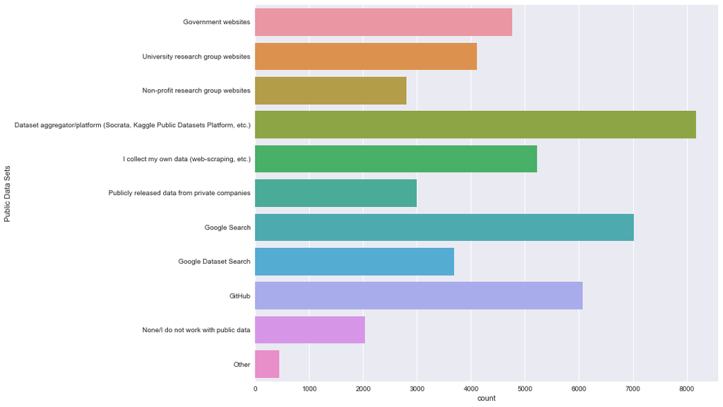

```python
generate_horizontal_countplot(y=publicDataSetsDF.publicDataSets,
                             ylabel = 'Public Data Sets',
                             figName = 'publicDataSets.jpeg')
```

We will persist the clean copy of the dataframe as a CSV file.

We no longer need "publicDataSetsDF" in the analysis. We will clean up from memory.

```python
publicDataSetsDF.to_csv('publicDataSets.csv',index=False)
```

```python
del publicDataSetsDF
gc.collect()
```

```
3241
```

### During a typical data science project at work or school, approximately what proportion of your time is devoted to the following?

- **Gathering data**
- **Cleaning data**
- **Visualizing data**
- **Model building/model selection**
- **Putting the model into production**
- **Finding insights in the data and communicating with stakeholders**

```python
dataScienceActivityDF = multipleChoiceDF[['Q34_Part_1', 'Q34_Part_2','Q34_Part_3', 'Q34_Part_4','Q34_Part_5',
                                          'Q34_Part_6']]
```

```python
dataScienceActivityDF.head()
```

|  | Q34_Part_1 | Q34_Part_2 | Q34_Part_3 | Q34_Part_4 | Q34_Part_5 | Q34_Part_6 |
| --- | --- | --- | --- | --- | --- | --- |
| 0 | During a typical data science project at work ... | During a typical data science project at work ... | During a typical data science project at work ... | During a typical data science project at work ... | During a typical data science project at work ... | During a typical data science project at work ... |
| 1 | NaN | NaN | NaN | NaN | NaN | NaN |
| 2 | NaN | NaN | NaN | NaN | NaN | NaN |
| 3 | 2 | 3 | 20 | 50 | 20 | 0 |
| 4 | 20 | 25 | 15 | 10 | 10 | 20 |

```python
dataScienceActivityDF.info()
```

```
<class 'pandas.core.frame.DataFrame'>
RangeIndex: 23860 entries, 0 to 23859
Data columns (total 6 columns):
Q34_Part_1    15938 non-null object
Q34_Part_2    15938 non-null object
Q34_Part_3    15938 non-null object
Q34_Part_4    15938 non-null object
Q34_Part_5    15938 non-null object
Q34_Part_6    15938 non-null object
dtypes: object(6)
memory usage: 1.1+ MB
```

```python
dataScienceActivityDF.drop([0],inplace=True)
dataScienceActivityDF.reset_index(drop=True,inplace=True)
```

```python
dataScienceActivityDF.rename(columns={"Q34_Part_1":"Gathering data",
                                 "Q34_Part_2":"Cleaning data",
                                 "Q34_Part_3":"Visualizing data",
                                 "Q34_Part_4":"Model building/model selection",
                                 "Q34_Part_5":"Putting the model into production",
                                 "Q34_Part_6":"Finding insights in the data and communicating with stakeholders"},
                        inplace = True)
```

```python
dataScienceActivityDF = pd.melt(dataScienceActivityDF)
```

```python
dataScienceActivityDF.head()
```

|  | variable | value |
| --- | --- | --- |
| 0 | Gathering data | NaN |
| 1 | Gathering data | NaN |
| 2 | Gathering data | 2 |
| 3 | Gathering data | 20 |
| 4 | Gathering data | 10 |

```python
dataScienceActivityDF.rename(columns={"variable":"Data-Science-Activity"},inplace=True)
```

```python
dataScienceActivityDF.sort_values("Data-Science-Activity",inplace=True)
dataScienceActivityDF.reset_index(drop=True,inplace=True)
```

```python
dataScienceActivityDF.dropna(inplace=True)
dataScienceActivityDF.reset_index(drop=True,inplace=True)
```

```python
dataScienceActivityDF['value']=dataScienceActivityDF.value.astype(float)
```

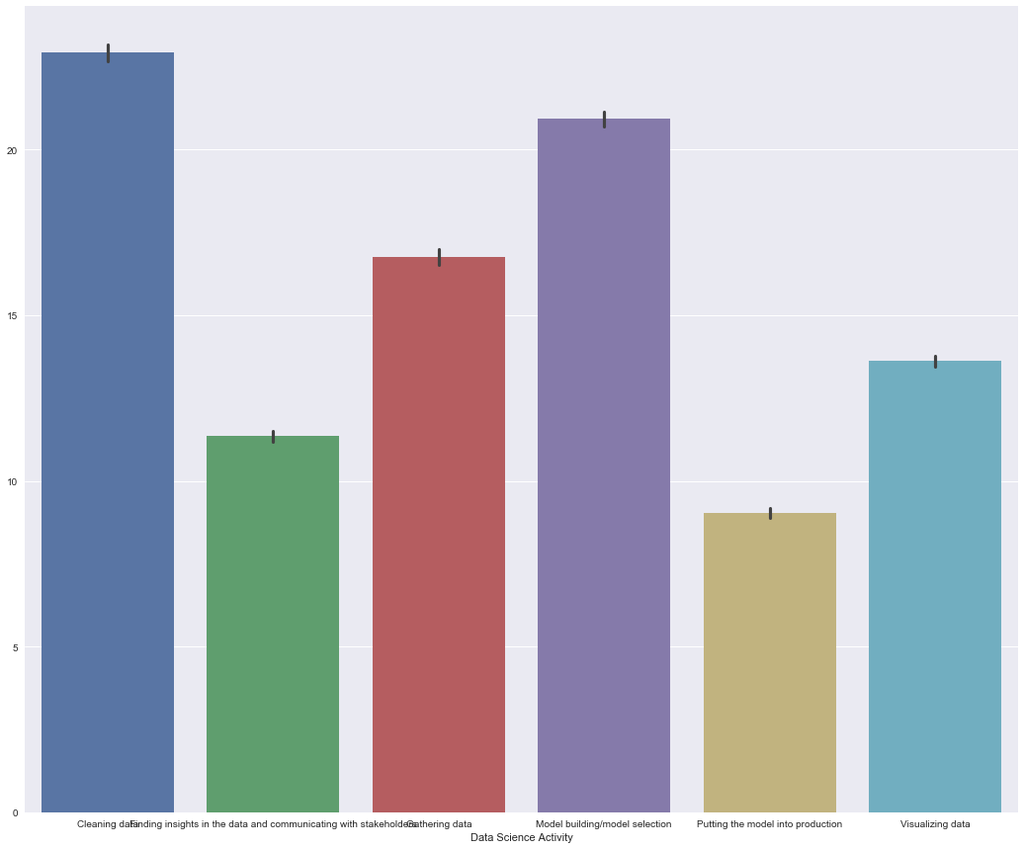

```python
generate_bar_plot(data=dataScienceActivityDF,
                  x="Data-Science-Activity",
                  y="value",
                  xlabel="Data Science Activity",
                  figName="Data Science Activity_Distribution.jpeg",
                  figSize=(18, 15))
```

We will persist the clean copy of the dataframe as a CSV file.

We no longer need "dataScienceActivityDF" in the analysis. We will clean up from memory.

```python
dataScienceActivityDF.to_csv('dataScienceActivity.csv',index=False)
```

```python
del dataScienceActivityDF
gc.collect()
```

```
2852
```

## Conclusion

In this notebook, we have analyzed various technical tools and utilities that are used in Machine learning and Data science projects.